# The Strength of Showing Weakness: Organizational Supplication and Investor Reactions to Workforce Downsizing

[figure not shown]

https://doi.org/10.1177/01492063251339412

Journal of Management Vol. XX No. X, Month XXXX 1–37

DOI: 10.1177/01492063251339412

© The Author(s) 2025

Article reuse guidelines: sagepub.com/journals-permissions

## The Strength of Showing Weakness: Organizational Supplication and Investor

## Reactions to Workforce Downsizing

#### *University of Mannheim* Louis Vandepoele

*University of Mannheim*

*Strategy research usually assumes that displays of weakness are disadvantageous for firms. In this study, we challenge this assumption. We propose that deliberate displays of weakness can help firms preserve stakeholder approval when taking controversial decisions. To test this proposition, we examine the use and effectiveness of organizational supplication in the context of workforce downsizing. Building on impression management theory, we predict that firms portray themselves as weak through downward earnings management before workforce downsizing announcements, and that this supplication tactic helps attenuate investors’ negative reactions. Moreover, we posit that supplication paired with an efficiency-focused verbal justification for the downsizing is particularly effective at attenuating negative investor reactions to downsizing announcements, as an additional verbal justification lends authenticity to the downsizing firm’s supplication attempt. Yet, we also theorize that organizational supplication through downward earnings management is less effective if positive firm evaluations by security analysts and the business media make it appear inauthentic. The empirical analysis of nearly 600 workforce downsizing announcements by the largest listed U.S. firms between 2001 and 2020 supports our theoretical predictions.*

*Keywords:* *impression management; downsizing/layoffs/restructuring; event study (financial)*

*Acknowledgments: We are sincerely grateful to associate editor Peggy Lee and two anonymous reviewers for their invaluable guidance throughout the review process.*

*Corresponding author: Matthias Brauer, Chair of Strategic and International Management, University of Mannheim, Schloss, Mannheim, 68131, Germany.*

*E-mail: matthias.brauer@uni-mannheim.de*

#### **Introduction**

The academic discourse in strategy research traditionally revolves around showcasing and leveraging organizational strengths (e.g., Ansoff, 1987; Learned, Christensen, Andrews, & Guth, 1969). It largely builds on the premise that appearing weak is detrimental to firms and thus should be avoided. In this study, we propose that the deliberate display of weakness can also be beneficial for firms, specifically when taking controversial decisions or actions. In our theorizing, we build on theory and research on organizational impression management (IM), which has generated valuable insights into how firms can influence stakeholder perceptions in a desirable way by strategically presenting or limiting available information (for reviews, see Bolino, Kacmar, Turnley, & Gilstrap, 2008; Bolino, Long, & Turnley, 2016). Yet, extant work on organizational IM has focused mostly on firms’ attempts to convey *positive* images to protect against negative stakeholder reactions, for example, through apologies, denials, or excuses (e.g., Elsbach, 1994, 2003; Elsbach, Sutton, & Principe, 1998; Lamin & Zaheer, 2012), the dissemination of positive news (Graffin, Haleblian, & Kiley, 2016; Short & Pfarrer, in press), or other IM tactics that emphasize positive firm attributes and behavior (e.g., Bass, Pfarrer, Milosevic, & Titus, 2023; McDonnell & King, 2013; Westphal & Graebner, 2010; Zavyalova, Pfarrer, Reger, & Shapiro, 2012).

In contrast, *negative* IM by which firms deliberately try to look bad to *attenuate* negative audience reactions has rarely been considered (Bolino et al., 2016). The few prior studies on negative organizational IM have focused on the strategic release of negative press releases before CEO stock option grants to reduce the options’ strike price (Quigley, Hubbard, Ward, & Graffin, 2020), the issuance of press releases, conference calls, and earnings guidance to lower analyst forecasts after a firm reported earnings above or below expectations (Washburn & Bromiley, 2014), and the concurrent release of additional negative news to *amplify* the impact of a negative event (so-called “big bath” or “amplification” tactics; e.g., Elliott & Shaw, 1988; Short & Pfarrer, in press; Walsh, Craig, & Clarke, 1991). While these studies have produced valuable insights into when and how firms deliberately induce or even amplify negative impressions among stakeholders, our scholarly understanding of whether firms also engage in negative IM tactics to *attenuate* the impact of controversial events is limited. This lack of knowledge is surprising, given that IM theory suggests that the deliberate display of weakness via supplication can be an effective means for firms to preserve stakeholder support (Bolino et al., 2008; Jones & Pittman, 1982; Leary, 1995).

Supplication relates to any attempts intended to elicit support, sympathy, and leniency by “portraying [oneself] as weak” (Bolino et al., 2008: 1082) or “helpless (handicapped, unfortunate)” (Jones & Pittman, 1982: 249). Proactively showcasing weakness via supplication thus constitutes a so far unexplored form of anticipatory IM, that is, “activities that are undertaken in anticipation of, or contemporaneously with, [a negative event]” (Graffin et al., 2016: 234) to influence audience reactions to the event (Elsbach et al., 1998; Graffin, Boivie, & Carpenter, 2011).

The study of supplication is theoretically relevant, in that it addresses the “need for research that broadens our understanding of [negative IM] tactics that are less well understood” (Bolino et al., 2008, 2016: 382). Moreover, knowledge on whether and under which conditions the use of negative IM tactics to convey a *weak* image reduces negative audience reactions to controversial firm decisions is an important complement to the rich body of literature on the effectiveness of positive organizational IM tactics.

To further our understanding of the use and effectiveness of negative IM tactics, we examine organizational supplication in the context of workforce downsizing. We use workforce downsizing, defined as an “intentional reduction in the number of people of an organization” (Brauer & Laamanen, 2014: 1313), as an empirical context because it elicits negative reactions by a firm’s key stakeholders, most notably investors (Cascio, Chatrath, & Christie-David, 2021; Datta & Basuil, 2015; Datta, Guthrie, Basuil, & Pandey, 2010). A review of prior literature shows that 35 of 39 empirical studies found that investors react negatively to downsizing announcements (see Appendix A). Workforce downsizing thus lends itself to the study of anticipatory, organizational IM attempts. The study of supplication in the context of downsizing is also of considerable practical interest. Downsizing has become a highly prevalent managerial practice in recent years. U.S. technology firms alone laid off more than 257,000 workers in 2023 and 124,000 in the first half of 2024 (Biron et al., 2023; Sayegh, 2024). The total number of job cuts in the United States surged to over 720,000 in 2023, an increase of 98% compared to 2022 and, apart from Covid-19-induced layoffs in 2020, the highest annual total since 2009 (Challenger, Gray, & Christmas, 2024). By examining the use and effectiveness of supplication in the context of workforce downsizing, we thus combine what McNamara and Schleicher (2024) labeled in a recent *Journal of Management* editorial the “theoretical insights path” and the “phenomenon-driven path” to build a substantive contribution.

Building on IM theory (Goffman, 1959; Leary, 1995; Schlenker, 1980), we posit that firms anticipate negative investor reactions to workforce downsizing and thus engage in supplication by intentionally lowering their performance through downward earnings management before a downsizing announcement. We further predict that supplication by means of downward earnings management is effective at attenuating investors’ negative reaction to downsizing announcements for two reasons: First, supplication makes a downsizing announcement less surprising for investors, as they will anticipate that the firm will announce restructuring measures to address the earnings shortfall. Second, supplication recasts downsizing as a “necessary evil” that a firm is forced to undertake to remedy the earnings shortfall. The decision to downsize thus appears logically compelling to investors, dampening their negative reaction.

As prior IM research “has examined [IM] tactics in isolation when, in fact, it is likely that IM tactics interact in meaningful ways” (Bolino et al., 2008: 1090), we further theorize that supplication is more effective if paired with a verbal justification. In IM literature, justifications are viewed as a form of positive IM, as actors provide explanations for a negative event or decision to escape disapproval (Bolino et al., 2008: 1082). Specifically, we reason that an efficiency-focused verbal justification lends authenticity to the downsizing firm’s supplication attempt and thus further helps attenuate investors’ negative reaction because investors view the downsizing as an appropriate and logically compelling decision to enhance efficiency.

In addition, our work extends established theoretical models of IM (i.e., Gardner & Martinko, 1988; Liden & Mitchell, 1988) by departing from the dyadic perspective on the IM process in prior IM literature and advocating a triadic perspective. Next to actor and audience, we theorize that infomediaries exert an important influence on the audience’s reaction to IM attempts. Specifically, we propose that evaluations of relevant infomediaries which are inconsistent with the impressions conveyed by the firm can lead the audience to deem firms’ IM attempts inauthentic. Hence, we reason that supplication is less effective if security

analysts and the business media—key infomediaries for investors—provide positive firm evaluations which disconfirm the weak image conveyed by a downsizing firm. Our empirical findings, based on 598 downsizing announcements by the largest listed U.S. firms between 2001 and 2020, fully support our theoretical predictions. Our study contributes to IM theory and literature in several respects. Our study’s unique focus on supplication, an unexplored *negative* organizational IM tactic (Bolino et al., 2008, 2016), allows us to generate novel insights into firms’ use of supplication and its effectiveness in the context of controversial decisions. Counter to the conventional emphasis in strategy research on displays of strength or power, our study reveals that deliberate displays of *weakness* can also be beneficial for firms. Our study thus uncovers a novel mechanism of how firms can positively bias audience reactions through IM tactics. Our work further extends IM theory and differs from past IM studies by going beyond the prevalent focus on single IM tactics. Our findings imply that the *congruent* use of negative, anticipatory IM (supplication) and positive, reactive IM (verbal justification) can be a particularly effective strategy for attenuating negative audience reactions.

In addition, our work extends existing theoretical frameworks of IM by considering the influence of infomediaries on the effectiveness of IM. While past IM research has conceptualized IM as a dyadic interaction between actor and audience, we advocate a triadic view which integrates infomediaries into the IM process. Our theorizing and empirical results suggest that the effectiveness of IM attempts hinges on the extent to which evaluations of relevant infomediaries confirm or disconfirm the desired image outcome.

Finally, our work advances workforce downsizing research. While investors’ negative reactions to downsizing are well documented, we innovate by highlighting how firms can effectively inhibit negative investor reactions to a downsizing announcement through supplication. We thereby extend the scarce research on downsizing firms’ IM attempts, which has so far exclusively studied positive IM tactics (e.g., Brauer & Vandepoele, 2024; Nègre, Verdier, Cho, & Patten, 2017; Zdaniuk & Chhinzer, 2019), and further our understanding of the sparsely explored contextual factors affecting investor reactions to downsizing (Datta et al., 2010; Datta, Basuil, & Radeva, 2012).

#### **Background**

*Investors’ Reaction to Workforce Downsizing Announcements*

Over the past 40 years, empirical research has consistently shown that, on average, workforce downsizing elicits negative investor reactions (see Datta & Basuil, 2015; Datta et al., 2010, 2012 for reviews; see Capelle-Blancard & Couderc, 2007; Eshghi & Astvansh, 2024 for meta-analyses). Out of 39 empirical studies (see Appendix A), 35 found negative shortterm stock returns around downsizing announcements (e.g., Brauer & Zimmermann, 2019; Hillier, Marshall, McColgan, & Werema, 2007; Lee, 1997; Nixon, Hitt, Lee, & Jeong, 2004; Worrell, Davidson, & Sharma, 1991).<sup>1</sup> A primary explanation for investors’ negative reaction is that workforce downsizing incurs substantial direct and indirect costs (e.g., Brauer & Zimmermann, 2019; Capelle-Blancard & Couderc, 2007; Datta et al., 2010, 2012; Eshghi & Astvansh, 2024). Direct costs include severance payments, outplacement service costs, or expenses for early retirement plans (Cascio, 1993; Cascio et al., 2021; Nixon et al., 2004). Due to these substantial one-off costs, it often takes significant time before the expected cost

savings materialize. In fact, the more extensive the downsizing the longer it generally takes for any positive impact to be reflected in the firm’s reported earnings. Investors have thus been found to react particularly negatively to large-scale downsizing (e.g., Brauer & Zimmermann, 2019; Lee, 1997).

Importantly, research has further argued and found that the *indirect* costs of workforce downsizing can be even more substantial (Cascio, 2010; De Meuse & Dai, 2012; Gerhart & Trevor, 1996). Indirect costs arise from knowledge losses as well as the disruption of organizational routines (Brauer & Laamanen, 2014; Nixon et al., 2004; Shah, 2000) and, most of all, negative psychological effects on those employees “surviving” the downsizing (Armstrong-Stassen, 1994; Brockner, Spreitzer, Mishra, Hochwarter, Pepper, & Weinberg, 2004; Cascio, 2010; De Meuse, Bergmann, Vanderheiden, & Roraff, 2004). “Survivors” often deal with a range of negative feelings, including guilt, fear, uncertainty, and demotivation, which have been found to lead to decreased job satisfaction, higher employee turnover and absenteeism, and lower job performance (e.g., Amabile & Conti, 1999; Brockner et al., 2004; De Meuse et al., 2004; Kets de Vries & Balazs, 1997; Trevor & Nyberg, 2008).

Due to these significant direct and indirect costs, downsizing is generally a measure of “last resort” (Cascio, 2005: 48) that investors perceive less negatively only in rare cases. Prior research suggests that negative investor reaction is less pronounced if workforce downsizing appears inevitable and well “thought through,” such as if the firm downsizes to stop a downward spiral (e.g., Eshghi & Astvansh, 2024: 798; Datta et al., 2012; Franz, Crawford, & Dwyer, 1998). Further, select studies reveal that investors tend to react less negatively in case a downsizing is temporary (Lee, 1997), forms part of a wider reorganization or restructuring strategy (Lee, 1997; Nixon et al., 2004), or when the downsizing firm provides a verbal excuse (Zdaniuk & Chhinzer, 2019). In total, prior research indicates that downsizing announcements elicit negative investor reactions, although their intensity may vary slightly. This suggests that firms will anticipate investors’ negative reactions and are motivated to use IM tactics to attenuate investors’ negative reactions.

#### **Theory and Hypotheses**

*Supplication as a Negative, Anticipatory Impression Management Tactic*

IM theory suggests that firms use supplication to advertise “weakness or shortcomings” to elicit audience leniency and support (Becker & Martin, 1995; Bolino & Turnley, 1999: 190; Bolino et al., 2008; Leary, 1995; Schlenker, 1980). Yet, empirical research on the use and effectiveness of supplication is scarce, and the few studies on the effect of individuals’ supplication in the workplace context have generated equivocal results.<sup>2</sup> While select studies suggest that supplication elicits supportive behavior by co-workers and helps to avoid undesirable tasks (Berkowitz & Daniels, 1964; Bolino et al., 2016), the majority of studies have found that supplication is associated with negative supervisor performance ratings and coworker evaluations (e.g., Chawla et al., 2021; Harris, Kacmar, Zivnuska, & Shaw, 2007; Kacmar, Carlson, & Harris, 2013; Turnley & Bolino, 2001). A possible explanation for the predominantly negative findings on supplication is that “employees’ intentionally looking bad in a work setting is very uncommon” (Becker & Martin, 1995: 175; Bolino & Turnley, 1999, 2003), as employees typically want to appear powerful and competent at work. As a

result, Turnley and Bolino (2001: 355) conclude that “[supplication’s] ‘desired’ image outcomes are of questionable value . . . in the context of work groups.”

Social psychology research offers further explanation for the ambiguous findings in individual-level IM literature on the effectiveness of supplication in the workplace context. Experimental findings suggest that displays of weakness are most effective if used in the context of failure or crisis (e.g., Crant & Bateman, 1993; Gibson & Sachau, 2000; Kowalski & Leary, 1990; Leary, 1995; Schouten & Handelsman, 1987). For instance, Gibson and Sachau’s (2000) study suggests that individuals who strategically feign inability prior to failure in a test successfully lower observers’ performance expectations, resulting in more lenient performance evaluations.

To summarize, although IM theory and select individual-level social psychology studies indicate that displays of weakness can be advantageous in specific contexts, the prevalence and effectiveness of intentional displays of weakness by firms remain largely unexplored and ill-understood. To address this void and advance IM theory, we argue in the following that firms frequently present themselves as weak prior to workforce downsizing announcements, thereby effectively mitigating negative investor reactions.

*Organizational Supplication in the Context of Workforce Downsizing*

Leary and Kowalski’s (1990) seminal process model of IM suggests that IM involves two main components: Impression motivation describes the extent to which actors intend to control how an audience perceives them. Impression construction refers to the specific images that actors aim to project. A firm’s decision to reduce its workforce serves as an appropriate context for this two-component process model. Due to investors’ predominantly negative reactions to workforce downsizing announcements, firms are strongly motivated to utilize IM tactics to avoid significant share price declines (Gardner & Martinko, 1988; Leary & Kowalski, 1990). Supplication appears an effective IM tactic to do so. As noted above, investors respond less negatively to downsizing when it appears necessary or inevitable (e.g., Datta et al., 2012; Eshghi & Astvansh, 2024; Franz et al., 1998; Iqbal & Shetty, 1995). A low-cost way for firms to convey this image is through supplication in the form of downward earnings management.

Earnings management refers to discretionary, lawful choices firms make in their financial reporting with the intent to “mislead . . . stakeholders about the underlying economic performance of the company” (Healy & Wahlen, 1999: 368; Chen, Luo, Tang, & Tong, 2015; Davidson, Jiraporn, Kim, & Nemec, 2004). Earnings management is a viable supplication tactic for several reasons: First, “[quarterly] earnings announcements are a dominant source of information in the equity market” (Basu, Duong, Markov, & Tan, 2013: 223). Survey research suggests that for chief financial officers the “two most important earnings benchmarks are quarterly earnings . . . and the analyst consensus estimate” (Graham, Harvey, & Rajgopal, 2005: 5). Abnormal stock volatility and abnormal returns around quarterly earnings announcements further evidence their importance to investors and other capital markets constituents (e.g., Basu et al., 2013; Dunham & Grandstaff, 2022; Nichols & Wahlen, 2004). Second, firms have high discretion over reported earnings and can usually alter them covertly, as it is difficult for investors and other stakeholders to detect earnings management (Graham et al., 2005; Healy & Wahlen, 1999). This makes earnings management a subtle and effective IM tactic.

Although past strategy work has mostly focused on upward earnings management by firms (e.g., Bascle & Jung, 2023; Chen et al., 2015; Davidson et al., 2004), selected studies in accounting and finance have shed light on when and why firms manage earnings downward. We organize this literature in Appendix B. Extant literature suggests that firms use downward earnings management around corporate events to reduce corporate expenses or take a “big bath” (e.g., Francis, Hasan, & Li, 2016; Gong, Louis, & Sun, 2008; Walsh et al., 1991). Building on these empirical insights, we argue that firms also deflate their earnings before downsizings for the purpose of supplication. Supplication is not intended to reduce expenses associated with a corporate event—such as the price of stock repurchases or stock options (Francis et al., 2016; Gong et al., 2008)—but, rather, to attenuate negative stakeholder reactions to the event. Supplication through downward earnings management is also fundamentally different from “big bath” accounting. While “big bath” accounting involves “a purported cleansing of the financial statements” (Elliott & Shaw, 1988: 92) or the release of “many negative announcements concurrently in an effort to clear out all of the firm’s bad news in one big splash” (Graffin et al., 2011: 766), supplication through downward earnings management occurs before a focal negative event and is not intended to “*overstate* the negativity of the event” (Graffin et al., 2016: 235, emphasis added) but to *reduce* its negative impact.

In summary, we predict, based on the two-component process model of IM by Leary and Kowalski (1990), that downsizing firms are motivated to utilize supplication through unusually high extents of downward earnings management to present themselves as weak, thereby construing the impression that the downsizing is necessary and inevitable. We thus state:

*Hypothesis 1*: Prior to workforce downsizing announcements, firms engage in supplication by

means of a higher extent of downward earnings management than is predicted by their baseline extent of downward earnings management.

*Organizational Supplication and Investor Reactions to Downsizing Announcements*

Drawing on IM theory and social psychology research (Fiske & Taylor, 2017; Gardner & Martinko, 1988; Goffman, 1959; Leary, 1995), we theorize next that supplication through downward earnings management attenuates investors’ negative reactions to workforce downsizing announcements because it makes a firm’s decision to downsize *less surprising* and *more logically compelling* to investors. Supplication through downward earnings management reduces the negative surprise for investors by serving as an “early warning signal.” Lower-than-expected performance leads investors to anticipate that a firm will take efficiency-enhancing actions, such as workforce downsizing, in the near term. Investors—like all humans—value predictability (Fiske & Taylor, 2017; Miceli & Castelfranchi, 2015), particularly in respect to a firm’s actions and performance (e.g., Brown, 2001; Pan, McNamara, Lee, Haleblian, & Devers, 2018; Skinner & Sloan, 2002). Hence, we predict workforce downsizing announcements preceded by supplication to be received less negatively by investors because they are taken less by surprise.

The second reason why supplication attenuates investors’ negative reaction is that it makes the decision to downsize appear more logically compelling. Given the considerable direct and indirect costs associated with workforce downsizing (e.g., Capelle-Blancard &

Couderc, 2007; Cascio et al., 2021; Datta et al., 2010; Nixon et al., 2004), firms need to persuade investors that such a severe restructuring measure is necessary. Supplication in the form of downward earnings management induces the impression among investors that downsizing is necessary to address the earnings shortfall and enhance operational efficiency. As firms usually downsize “with the goal of improving firm [operating] performance” (Budros, 1997; Datta et al., 2010: 282; Guthrie & Datta, 2008), the decision to downsize appears consonant with the wide-spread cognitive schema that downsizing is “a natural, acceptable strategy” to remedy performance shortfalls (McKinley, Zhao, & Rust, 2000: 235). Hence, investors are more likely to perceive the focal workforce downsizing as an appropriate managerial response. Given that greater adequacy and understandability of firm decisions and actions have been argued and shown to result in more favorable audience evaluations (Ashforth & Gibbs, 1990; Elsbach, 1994; Elsbach & Elofson, 2000; Suchman, 1995; Westphal & Graebner, 2010), we expect investors to evaluate workforce downsizing announcements less negatively when firms have engaged in supplication beforehand. Taken together, our theoretical arguments lead to the following hypothesis:

*Hypothesis 2*: Supplication through downward earnings management is associated with a less nega-

tive investor reaction to a workforce downsizing announcement.

*Boundary Condition: The Authenticity of Organizational Supplication Attempts*

IM theory suggests that authenticity is a key prerequisite for IM attempts to be successful (Gardner & Martinko, 1988; Goffman, 1959; Leary, 1995). Prior IM research has argued that IM attempts are deemed authentic if they are consistent with the actor’s characteristics and reputation, for example, if an applicant with a reputation for competence engages in self-promotion in a job interview (Bolino et al., 2016; Leary, 1995; Roulin, Bangerter, & Levashina, 2015). Similarly, authenticity research has argued that “authenticity is a cross-level mechanism through which organizations and their individual members orchestrate a coherent impression” (Lamertz, 2022: 3). However, while the importance of authenticity for IM’s effectiveness has been conceptually recognized, prior empirical work has omitted to systematically examine whether the authenticity of an actor’s IM attempts constitutes a critical boundary condition (Bolino et al., 2016). To address this gap in IM literature, we theorize next that the extent to which supplication attenuates investors’ negative reaction to downsizing announcements depends on its perceived authenticity. We contend that supplication appears more authentic when a firm’s verbal justification for downsizing aligns with its display of financial weakness. Conversely, we argue that it is perceived as inauthentic if positive evaluations from security analysts and the business media disconfirm its display of weakness.

*The interplay of verbal justification and supplication.* Justification is a positive, reactive IM tactic aimed to “minimize the perceived negativity of an event” (Bolino et al., 2008; Elsbach, 2003: 307). Prior studies have shown that firms frequently justify workforce downsizing decisions, for example, by stressing the need to cut costs to improve efficiency (e.g., Hillier et al., 2007; Nègre et al., 2017; Zdaniuk & Chhinzer, 2019). Next to the practical relevance of justifications in the context of workforce downsizing, we see theoretical value in considering how a firm’s justification influences the effectiveness of its supplication

attempts. Examining the interplay of supplication and verbal justification is theoretically valuable, as prior reviews of IM literature lament that we lack knowledge of “how the use of [IM] tactics in combination influences observer reactions” (Bolino et al., 2008, 2016: 391). In particular, the combination of negative IM tactics (i.e., supplication) and positive IM tactics (i.e., justification) remains unexplored.

We posit that supplication and efficiency-focused verbal justifications can reinforce each other in the context of workforce downsizing. Efficiency considerations and poor financial performance are the most prevalent determinants of workforce downsizing (Cascio et al., 2021; Datta et al., 2010). If a firm acknowledges that it struggles with cost issues and needs to improve efficiency, this reinforces its previous display of weakness and underscores that downsizing constitutes a “necessary evil” to address its earnings shortfall. When paired with an efficiency-focused verbal justification for the downsizing decision, supplication through downward earnings management appears authentic, thereby enhancing its effectiveness in convincing investors of the logical soundness and appropriateness of the firm’s decision to downsize. Hence, we hypothesize:

*Hypothesis 3*: An efficiency-focused verbal justification by a firm for its workforce downsizing

strengthens the attenuating effect of supplication on investor reaction to a workforce downsizing announcement.

*The interplay of security analyst and business media evaluations and supplication.* Security analysts constantly gather, process, and evaluate information on firms to issue earnings forecasts and recommendations on whether to buy, hold, or sell a firm’s stock. Because of their high perceived expertise, independence, and the fact that their status and career success depend on the accuracy of their assessments, security analysts serve as knowledgeable and trusted experts on a firm for investors (Bascle & Jung, 2023; Brauer & Wiersema, 2018; König, Mammen, Luger, Fehn, & Enders, 2018; Wiersema & Zhang, 2011). Likewise, the business media acts as a key infomediary group for investors by reducing information asymmetry and evaluating firms and their behaviors (e.g., Bednar, 2012; Graf-Vlachy, Oliver, Banfield, König, & Bundy, 2020; König et al., 2018; Oliver, Campbell, Graffin, & Bundy, 2023). Media coverage not only mirrors public opinion but also actively directs stakeholders’ attention to issues, and influences public perceptions of a firm through positive or negative coverage (Bednar, 2012; Graf-Vlachy et al., 2020).

If security analysts evaluate a firm favorably, as evidenced by positive revisions of their stock recommendations, investors assess the firm’s performance to be improving (Barber, Lehavy, & Trueman, 2010; Stickel, 1992; Womack, 1996). Likewise, empirical research suggests that positive media evaluations, as evidenced by the tone of media reports about a firm, indicate sustainable competitive advantages and improving performance (Deephouse, 2000; Graf-Vlachy et al., 2020; Pfarrer, Pollock, & Rindova, 2010; Oliver et al., 2023). In the light of positive security analyst recommendations or positively toned media articles, a firm’s attempt to convey an image of financial weakness through downward earnings management appears inauthentic. As a result, we predict that supplication is less effective in reducing negative investor reactions to downsizing when security analyst recommendations or business media articles on a firm have been positive.

In contrast, we posit that security analysts and the business media can unintentionally offer indirect IM support if their evaluations of the downsizing firm are unfavorable. Negative

revisions of analyst recommendations indicate to investors that the firm’s earnings prospects are worsening (Barber et al., 2010; Stickel, 1992; Wiersema & Zhang, 2011; Womack, 1996). Similarly, negative media coverage indicates performance problems and “serve[s] as a powerful signal that current strategies and policies are inadequate and that change is needed” (Bednar, Boivie, & Prince, 2013: 914). Negative security analyst and business media evaluations thus lend greater authenticity to a firm’s deliberate display of weakness through downward earnings management. Therefore, we expect supplication to be more effective at attenuating negative investor reactions to downsizing if security analyst or business media evaluations of a firm have been negative. In sum, we predict:

*Hypothesis 4*: The more favorable security analysts’ evaluations of a firm prior to its workforce

downsizing announcement, the weaker is the attenuating effect of supplication on investor reaction to a workforce downsizing announcement. *Hypothesis 5*: The more favorable business media evaluations of a firm prior to its workforce down-

sizing announcement, the weaker is the attenuating effect of supplication on investor reaction to a workforce downsizing announcement.

#### **Methods**

*Sample and Data Collection*

To test our theoretical predictions, we sampled all downsizing announcements by the 250 largest U.S. firms as identified by *Fortune* between January 2001 and December 2020. We use the *Fortune 250*, which is a subset of the *Fortune 500* and includes the *Fortune 100*, for two reasons. First, our study requires that the firms in our sample are publicly listed and extensively monitored by capital markets and the media. These conditions are typically fulfilled by large and visible firms which have stocks that are widely traded, such as the *Fortune 250*. Second, we chose to base our study on the *Fortune 250* to ensure comparability with prior downsizing studies, which have typically utilized *Fortune 100*, *250*, or *500* samples (e.g., Brauer & Zimmermann, 2019; Budros, 1997, 2002, 2004; Chalos & Chen, 2002; Farber & Hallock, 2009; Love & Kraatz, 2009; Wayhan & Werner, 2000). Admittedly, a caveat of this sample scope is that it does not reflect the full variability in firm size among U.S. firms. We sampled the *Fortune* 250 as of 2001, since that was the first year after the Dotcom crisis and the passing of the Regulation Fair Disclosure Act in 2000—two influential events that altered the composition of the *Fortune* 250 and the rules for disclosing workforce reductions. We excluded 17 private firms included in the *Fortune* 250, as stock market data were missing to assess investor reactions. This left us with 233 sample firms.

To identify all the workforce downsizing announcements of our sample firms, we used the “layoffs/redundancies” news category of the Factiva database to collect all news articles on each firm published in the *Wall Street Journal*, *Reuters Newswire*, or *Dow Jones Newswire*. Following past research (e.g., Farber & Hallock, 2009; Schulz & Himme, 2022), we then manually screened the articles’ headlines and abstracts to verify that an article provides actual information on a workforce downsizing event by the sample firm. We only focused on initial downsizing announcements, that is, the first announcement with the earliest date by a firm on a downsizing. We then analyzed these initial downsizing announcements. Specifically, we gathered information on the number and percentage of downsized workers, and how a firm justified its downsizing.

In total, we were able to identify 1,616 initial downsizing announcements by our sample firms. To identify confounding events, we adopted the approach by Graffin et al. (2011, 2016) and McWilliams and Siegel (1997). We screened all press releases by sample firms during the event window using a pre-specified guideline with 23 confounding event types. In line with past IM research (Graffin et al., 2011, 2016), we distinguish between confounding events beyond a firm’s control (i.e., allegations of misconduct, lawsuits) and those under a firm’s control (e.g., dividend, acquisition, or earnings announcements). While we exclude the former, we control for the latter, recognizing they might reflect deliberate IM attempts (Graffin et al., 2011; Jin, Li, & Hoskisson, 2022). As a result of this approach, we dropped 14 observations that were confounded by other downsizings by the same firm and 85 observations that were confounded by events beyond the focal firm’s control (i.e., allegations of misconduct, bankruptcy, class action and other lawsuits). Moreover, we had to exclude 63 downsizings due to missing data on the number of downsized workers and 773 downsizings due to missing data on quarterly financial items (e.g., accounts receivable or property, plant, and equipment), which we needed to calculate the earnings management measure and other control variables.<sup>3</sup> Finally, we excluded 83 downsizings due to missing data on stock returns, security analyst recommendations, or business media coverage. Our final sample thus consists of 598 downsizing announcements by 103 firms. The share of retained observations (37%) compares favorably with similar studies (ca. 30%) that use quarterly financial data to measure earnings management (Chen et al., 2015). The number of downsizings in our sample also still exceeds the average sample size of prior studies (*N* = 437) on investor reactions to downsizing (see Appendix A). On average, the firms in our final sample downsized about six times during the sample period and dismissed about 2,730 employees per downsizing.

We used Refinitiv Eikon and Compustat to collect quarterly financial data on our sample firms, such as their size, profitability, debt-to-equity ratio, level of diversification, and all balance sheet items needed to calculate our earnings management measure. For data on industry-level workforce reductions, we relied on the U.S. Bureau of Labor Statistics. To obtain press releases around each downsizing, we drew on PR Newswire and Business Wire, the two dominant press release distributors (Graffin et al., 2016; Zavyalova et al., 2012). In line with prior works (e.g., König et al., 2018; Lamin & Zaheer, 2012), we used Factiva and LexisNexis to collect all media reports on our sample firms in the *New York Times* and *Wall Street Journal*. We chose to focus on these two general media outlets, as they fit our study’s focus on investors as a general rather than an expert audience (see Hubbard, Pollock, Pfarrer, & Rindova, 2018), and as they are the two top-circulating newspapers in the United States (Wolfe, 2012). Focusing on these leading outlets also helps to avoid the bias from mimetic “pack journalism” (König et al., 2018). In addition, we gathered data on security analysts’ recommendations from Refinitiv I/B/E/S and data on stock prices and market values of our sample firms from the Center of Research in Security Prices (CRSP).

*Key Outcome and Predictor Variables*

*Investor reaction to workforce downsizing announcements.* Following prior research on workforce downsizing (Farber & Hallock, 2009; Nixon et al., 2004; Worrell et al., 1991), we conducted an event study to examine the short-term *investor reaction* to workforce downsizing and computed abnormal returns on our sample firms’ stock during an event window surrounding the initial announcement day of a workforce downsizing (McWilliams & Siegel,

1997). Abnormal returns constitute the difference between the actual return on a firm’s stock and the estimated return calculated via an economic model for the same stock. To derive cumulative abnormal returns (CAR), we then summed up the daily abnormal returns within the event window. Collectively, we assessed the CAR for each of our sample firms by applying the following formula:

**equation / math rendering (image)**

**equation / math rendering (image)**

where *Ri t*, is the return on stock *i* for day *t*, *ai* a constant, β*i* the β of stock *i*, *Rm t*, the return on the value-weighted market portfolio for day *t*, and *T*1 and *T*2 the lower and upper limits of the event window. We compute expected returns using the CRSP Value Weighted Index during a 250-day estimation window from 295 to 45 days prior to the announcement day (McWilliams & Siegel, 1997). Like prior studies (Nixon et al., 2004; McWilliams & Siegel, 1997), we use a narrow 3-day event window (i.e., Day −1 to Day +1) to prevent confounding events from affecting our event study results, but to still account for information leaks and delayed stock price adjustments.

*Supplication.* To assess firms’ *supplication* attempts, we utilize the most prevalent measure to capture firms’ earnings management: discretionary accruals (Dechow, Sloan, & Sweeney, 1995; Healy & Wahlen, 1999; Jones, 1991; Ronen & Yaari, 2008). Accruals (including nondiscretionary and discretionary components) represent differences in reported earnings and balance sheet items that result because the time at which income or expense is recorded and the time at which cash is received or paid for a transaction often diverge (e.g., Chen et al., 2015; Healy & Wahlen, 1999; Ronen & Yaari, 2008). While nondiscretionary accruals are mandatory expenses or assets that have yet to be realized, firms have extensive control over the discretionary accruals that influence reported earnings. Thus, earnings management scholars usually decompose accruals into a nondiscretionary and discretionary component using an estimation model to infer the extent a firm manipulates its earnings (Dechow et al., 1995; Healy & Wahlen, 1999; Jones, 1991). Like prior studies (e.g., Bascle & Jung, 2023; Chen et al., 2015; Davidson et al., 2004; Dechow et al., 1995; Ronen & Yaari, 2008), we calculate discretionary accruals using the modified Jones model. Under the modified Jones model, a firm’s total accruals are calculated as the difference between reported earnings and cash flow. The nondiscretionary part of total accruals increases with sales growth, assets growth, and depreciation expenses, which depend on the value of a firm’s property, plant, and equipment. The difference between total accruals and its nondiscretionary component reflects the discretionary accruals. Following Chen et al. (2015), we estimate the modified Jones model by industry quarter (see Appendix C). As we examine downward earnings management, we only focus on the level of negative discretionary accruals. Accordingly, if discretionary accruals are positive, our key predictor variable supplication is zero. To facilitate interpretation, we use the absolute value of negative discretionary accruals in our analyses. A higher value therefore indicates a higher extent of downward earnings management in the quarter before a downsizing announcement (i.e., Quarter −1; Chen et al., 2015; Gong et al., 2008).<sup>4</sup>

*Efficiency-focused justification.* We measured *efficiency-focused (verbal) justification* as a dummy variable, which equals one if a firm states in its downsizing announcement that the

need to “cut costs,” “improve efficiency,” or “enhance financial performance” motivate the downsizing, and zero otherwise. This measurement follows prior downsizing studies (e.g., Farber & Hallock, 2009; Hillier et al., 2007; Palmon, Sun, & Tang, 1997; Schulz & Himme, 2022) as well as prior research on justifications as a reactive IM tactic (e.g., Lamin & Zaheer, 2012; Marcus & Goodman, 1991; Nègre et al., 2017). To conduct our coding, we followed prior research (e.g., Farber & Hallock, 2009; Lamin & Zaheer, 2012) and first developed a coding guideline in which we defined five types of justifications: enhance efficiency, decline in demand, mergers and acquisitions (M&A), other, and missing. Using this coding guideline, the second author and a trained research assistant read all announcements and carried out the coding, equally dividing the work. The research assistant was provided with the coding guideline, anchoring examples, as well as counterexamples beforehand, and was trained using a random sample of 50 downsizing announcements (about 8% of our final sample). We evaluated interrater reliability using Krippendorff’s alpha, which was equal to 0.93, indicating high agreement between both coders (Hayes & Krippendorff, 2007).

*Favorability of security analyst evaluations.* To gauge the *favorability of security analyst evaluations* before downsizing announcements, we use analysts’ stock recommendations (Fanelli, Misangyi, & Tosi, 2009; Wiersema & Zhang, 2011). Consistent with our operationalization of supplication, and consistent with the time intervals in which analysts revise their recommendations, we measure the change of analyst recommendations between the quarter prior to a downsizing announcement (i.e., Day −90 to −1) and the quarter before that (i.e., Day −180 to −91). Following prior research (e.g., Fanelli et al., 2009; König et al., 2018; Wiersema & Zhang, 2011), we relied on the code system provided by Refinitiv I/B/E/S to derive the favorability of security analyst recommendations and classified analyst recommendations as positive (I/B/E/S Codes 1 and 2, i.e., “strong buy” or “buy”), negative (I/B/E/S Codes 4 and 5, i.e., “sell” or “strong sell”), or neutral (I/B/E/S Code 3, i.e., “hold”). To aggregate individual analyst recommendations to an overall measure of the favorability of security analysts’ recommendations, we computed the Janis-Fadner coefficient of imbalance (e.g., Janis & Fadner, 1943; König et al., 2018). In doing so, we calculated the ratio of positive recommendations to negative recommendations in the quarter before a downsizing announcement, while accounting for the total number of analyst recommendations in the same period. From the resulting favorability of analyst evaluations measure, we subtracted a baseline value of the (expected) favorability of analyst evaluations in the 3 months prior to the quarter preceding each downsizing announcement of our sample firms (i.e., Day −180 to −91) to capture the (abnormal) favorability of analysts’ evaluations (König et al., 2018).

*Favorability of business media evaluations.* In line with prior research (e.g., Deephouse, 2000; König et al., 2018; Pollock & Rindova, 2003), we conducted a content analysis of all articles in the *New York Times* and *Wall Street Journal* on each of our sample firms (ca. 60,000 articles) to assess the *favorability of business media evaluations* before a downsizing announcement. Consistent with our measure for the favorability of security analyst evaluations, we examined all articles in the quarter before a downsizing announcement (i.e., Day −90 to Day −1) and the quarter prior to that (i.e., Day −180 to −91). Following prior media works (Bednar, 2012; Pfarrer et al., 2010; Pollock & Rindova, 2003; Zavyalova et al., 2012), we used the textual analysis software *Linguistic Inquiry and Word Count (LIWC)*, which

contains pre-defined and pre-validated dictionaries of words measuring positive and negative tone in a text (Pennebaker, Boyd, Jordan, & Blackburn, 2015), to determine the rate at which positive and negative affective language were reflected in a media article. We coded an article as positive if its affective content was at least 66% positive, and as negative if its affective content was at least 66% negative. We then calculated the Janis-Fadner coefficient to assess the favorability of media evaluations in the quarter prior to a downsizing (Deephouse, 2000; Janis & Fadner, 1943) and derived the (abnormal) favorability of media evaluations in this quarter by deducting the (expected) favorability of media evaluations in a baseline period 3 months before the quarter preceding a downsizing (i.e., Day −180 to −91).

*Control Variables*

Our first set of control variables relates to the content of firms’ downsizing announcements. Research suggests that as the magnitude of workforce downsizing increases, investor reactions tend to become more negative (e.g., Lee, 1997; Nixon et al., 2004; Worrell et al., 1991). Hence, we control for *downsizing magnitude* measured as the percentage of downsized employees relative to total employees. Moreover, we account for a firm’s justification for its downsizing, as it has been shown to affect investors’ reaction (e.g., Farber & Hallock, 2009; Nègre et al., 2017; Zdaniuk & Chhinzer, 2019). Following prior research (Farber & Hallock, 2009; Hillier et al., 2007; Palmon et al., 1997), we thus include four binary control variables in all models based on the manual coding of our sample firms’ downsizing announcements reported above: *efficiency-focused*, *demand-focused*, *M&A-related*, and *other justification*. Each of these binary variables equals one if a firm made use of the respective type of justification and zero otherwise.

Furthermore, we control for the timing of a downsizing announcement and downsizing firms’ press releases and upward earnings management. As investors typically attend less to news that is published on a Friday, firms could use this tendency to avoid a negative investor reaction by announcing their downsizing on a Friday (DellaVigna & Pollet, 2009). Hence, we include a dummy variable that takes on the value of one when a *Friday announcement* was present, and zero otherwise. Prior research further suggests that investor reaction is influenced by the prevalence of downsizing in an industry (Brauer & Zimmermann, 2019; Lee, 1997). To account for this effect, we follow the approach by Brauer and Zimmermann (2019) to identify industry downsizing waves and include an *industry downsizing wave* dummy variable in all analyses. The variable equals one if a downsizing is announced within an industry downsizing wave, and zero otherwise. As firms may deliberately disseminate confounding press releases around negative events to influence investor perceptions (so-called *strategic noise*), we account for the number of press releases, i.e., all positive, neutral, and negative news releases, issued by a firm in the 3-day event window (Graffin et al., 2011; Jin et al., 2022). We also control for the *extent of upward earnings management*. Consistent with our operationalization of supplication, we measure this variable as the absolute value of positive discretionary accruals in the quarter prior to a downsizing.

Additionally, we consider several firm characteristics which may influence investor reaction to downsizing announcements. As more extensive analyst and media coverage are likely to lead to greater investor scrutiny, we control for *security analyst coverage* of a firm, measured as the number of security analysts who provide recommendations for the firm in the

90 days before a downsizing announcement, and for *business media coverage*, measured as the number of media articles published in the quarter prior to each downsizing (Fanelli et al., 2009; König et al., 2018; Wiersema & Zhang, 2011). We also account for *firm size* measured as the natural logarithm of a firm’s total assets (König et al., 2018; Nixon et al., 2004). We further control for *firm performance* and *firm leverage* measured as the quarterly change in a firm’s industry-adjusted return on assets and in its debt-to-equity ratio (Elayan, Swales, Maris, & Scott, 1998; Hillier et al., 2007). Moreover, we account for *firm diversification* measured as the Herfindahl-Hirschman index of concentration of a firm’s sales (Hou & Robinson, 2006). We measure all firm controls in the quarter prior to a downsizing announcement. Lastly, we include industry and year fixed effects in all our analyses.

*Data Analysis*

To test Hypothesis 1, we adopt the methodological approach of prior anticipatory IM works (Graffin et al., 2011, 2016) and compare a firm’s extent of downward earnings management in the quarter immediately preceding a downsizing announcement with the baseline extent of downward earnings management in the previous four quarters (i.e., Quarter −5 to −2) using a paired *t* test.

For our tests of Hypotheses 2 to 5, we use ordinary least squares (OLS) regression analysis with cluster-robust standard errors. As we have pooled cross-sectional data and observe firms only when they downsize, this approach is most suitable (Wooldridge, 2010). Nonetheless, when we re-run our analyses using a random-effects and fixed-effects approach, we obtain fully consistent results. We include robust standard errors clustered by firms to account for heteroskedasticity and multiple downsizings by the same firm. In all interaction tests, we mean-centered the component variables. We examined multicollinearity by deriving variance inflation factors (VIF) for all analyses. The maximum VIF of our key predictor variables is 1.29, and the average VIF in our models is 2.29, suggesting that multicollinearity is not an issue in our models (Chatterjee & Hadi, 2012). Finally, we conducted supplementary analyses to account for endogeneity. Results of a two-stage least squares (2SLS) regression analysis and a Heckman two-stage model fully support the findings of our OLS models and are reported below.

#### **Results**

Table 1 presents descriptive statistics and correlations of all variables in our analyses. Consistent with prior research on workforce downsizing (e.g., Datta & Basuil, 2015; Datta et al., 2010, 2012; Eshghi & Astvansh, 2024; Hillier et al., 2007; Nixon et al., 2004; Worrell et al., 1991), we find that the average CAR over the 3-day event window is −0.39%. In line with prior downsizing studies, a *t* test shows that this negative investor reaction to workforce downsizing announcements is statistically significant (*t* = 1.85, *p* = .032). Equally, in line with prior downsizing research (e.g., Brauer & Zimmermann, 2019; Hillier et al., 2007; Lee, 1997; Nixon et al., 2004), we observe that downsizing magnitude is negatively correlated with investor reaction (*r =* −.12). In contrast, our key predictor variable supplication is positively correlated with CAR around workforce downsizing announcements (*r =* .09), providing initial support for Hypothesis 2.

**Table 1**

#### **Descriptive Statistics and Correlations**

Variables Mean *SD* 1 2 3 4 5 6 7 8 9 10 11 12 13 14 15 16 17 18 19

1. Investor reaction to workforce downsizing announcements −0.39 5.11

2. Supplication 0.07 0.15 0.09

3. Efficiency-focused justification 0.58 0.49 0.07 0.05

4. Favorability of security analyst evaluations 0.00 0.50 0.08 −0.01 0.02

5. Favorability of business media evaluations 0.01 0.29 0.00 0.06 0.11 0.02

6. Downsizing magnitude 0.03 0.05 −0.12 0.07 0.06 −0.02 0.07

7. Demand-focused justification 0.28 0.45 −0.08 −0.07 −0.73 −0.04 −0.14 −0.10

8. M&A-focused justification 0.05 0.21 −0.02 0.02 −0.26 0.05 0.02 0.04 −0.14

9. Other justification 0.04 0.20 0.01 0.02 −0.25 −0.02 0.03 0.07 −0.13 −0.05

10. Missing justification 0.05 0.23 0.00 −0.02 −0.28 0.02 0.00 −0.03 −0.15 −0.05 −0.05

11. Friday announcement 0.16 0.37 0.03 −0.01 0.04 0.05 −0.03 −0.04 0.00 −0.03 −0.05 0.00

12. Industry downsizing wave 0.25 0.43 −0.01 −0.05 −0.10 −0.04 −0.02 0.13 0.06 −0.06 0.05 0.10 −0.06

13. Number of confounding press releases (“strategic noise”) 1.27 1.59 0.06 −0.01 0.00 0.04 −0.05 0.01 0.01 0.08 −0.07 −0.03 −0.15 −0.04

14. Extent of upward earnings management 0.08 0.21 0.00 −0.18 0.00 −0.01 0.04 0.05 0.01 0.05 −0.04 −0.02 −0.09 0.08 0.04

15. Security analyst coverage 4.55 2.99 −0.04 0.10 0.04 −0.02 0.01 0.08 −0.02 −0.01 −0.03 −0.01 0.03 −0.11 0.13 0.01

16. Business media coverage 49.32 48.62 0.07 −0.03 −0.01 −0.03 −0.03 −0.11 0.01 0.04 −0.03 0.00 −0.03 −0.12 0.18 0.03 0.29

17. Firm size 10.71 0.98 0.04 0.03 0.10 −0.05 −0.01 −0.15 −0.11 0.06 0.05 −0.09 0.03 0.06 0.06 0.07 0.04 0.53

18. Firm performance −0.00 0.05 0.10 0.08 −0.04 0.03 0.09 −0.08 0.08 −0.01 0.00 −0.05 −0.01 0.01 0.00 0.00 −0.12 −0.03 0.07

19. Firm leverage 0.11 2.27 −0.01 −0.01 0.01 0.04 0.05 0.00 −0.01 0.00 −0.02 0.02 0.00 0.01 −0.01 −0.06 −0.01 0.05 0.01 −0.06

20. Firm diversification 0.48 0.25 0.04 −0.07 0.03 −0.09 0.00 0.12 −0.06 −0.02 0.06 0.00 −0.02 −0.02 −0.08 −0.07 −0.05 −0.05 −0.18 −0.09 0.08

*Note. N* = 598. Absolute values of correlations greater than 0.10 are significant at *p* < .01, and absolute values of correlations greater than 0.08 are significant at *p* < .05.

In Hypothesis 1, we argued that firms engage in supplication by means of a higher extent of downward earnings management prior to downsizing announcements compared to the baseline period. We observe that, during the four-quarter baseline period until one quarter prior to the downsizing announcement (i.e., Quarter −5 to −2), the extent of downward earnings management is equal to 0.045. In contrast, in the quarter before a downsizing announcement, the extent of downward earnings management used by our sample firms increases substantially to 0.066, with 291 out of 598 workforce downsizings or 48.7% of all events in our final sample, showing a downward manipulation of a downsizing firm’s reported earnings. Hence, firms engage in about 45% more downward earnings management prior to a downsizing. This difference in the extent of earnings management prior to a workforce downsizing announcement compared to the baseline period is highly significant (*t* = 3.00, *p* = .001). Hypothesis 1 is thus strongly supported.

Hypothesis 3 argued that an efficiency-focused justification for a downsizing amplifies supplication’s positive effect on investor reaction to a workforce downsizing announcement.

**Table 2 Results of OLS Regression Analysis Predicting Investor Reaction to Workforce**

#### **Downsizing Announcements**

[output not shown]

*Note. N* = 598. All models include industry and year fixed effects. Cluster-robust standard errors are provided in parentheses. **p* < .10. ***p* < .05. ****p* < .01 (two-tailed tests).

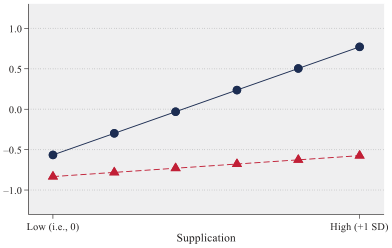

As shown in Model 3 of Table 2, the coefficient of the interaction term is positive and statistically significant (β = 4.99, *p* = .014), thereby supporting Hypothesis 3. We confirm these effects using a simple slopes analysis. The slope for the effect of supplication is positive and highly significant (*p* < .001) when the firm offers an efficiency-focused justification, but positive and non-significant (*p* = .365) in its absence. Figure 1 provides a graphical illustration of the moderating effect.

Hypothesis 4 posited that favorable security analyst evaluations attenuate the positive effect of supplication on investor reaction to a workforce downsizing announcement. Model 4 of Table 2 supports this hypothesis, as the coefficient of the interaction term is negative and statistically significant (β = −8.84, *p* = .022). A simple slope analysis again confirms this finding. Supplication’s effect is positive and non-significant (*p* = .871) when the favorability of security analyst evaluations is positive (i.e., mean plus one standard deviation), but positive and significant (*p* = .002) when the favorability of security analyst evaluations is negative (i.e., mean minus one standard deviation). Figure 2 graphically depicts the moderating effect.

Hypothesis 5 predicted that favorable business media evaluations attenuate the positive association of supplication and investor reaction to a workforce downsizing announcement. As displayed in Model 5 of Table 2, the coefficient of the interaction term is negative and significant (β = −10.80, *p* = .047). Hence, Hypothesis 5 is also supported. In line with our prediction, the slope for the effect of supplication is positive yet non-significant (*p* = .166) when the favorability of business media evaluations is positive (i.e., mean plus one standard deviation) and positive and significant (*p* = .001) when the favorability of business media evaluations is negative (i.e., mean minus one standard deviation). Figure 3 visualizes the effect. Finally, Model 6 of Table 2 reports the full model. The coefficient estimates for all hypothesized relationships remain consistent.

**Figure 1 Moderating Effect of Efficiency-Focused Justifications on the Relationship Between**

#### **Supplication and Investor Reaction to Workforce Downsizing Announcements**

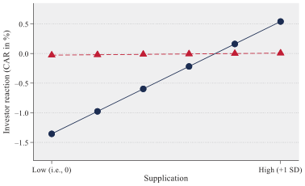

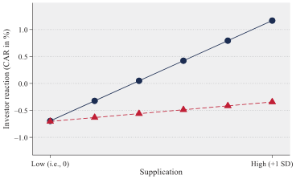

*Supplementary Analyses*

Next to the 2SLS analysis reported above, we performed several other supplementary analyses to test the robustness of our empirical results. First, we completed additional analyses to corroborate our finding that firms use an unusually high extent of downward earnings management before downsizing announcements, as predicted by Hypothesis 1. Specifically,

**Figure 2 Moderating Effect of Favorability of Security Analyst Evaluations on the Relationship Between Supplication and Investor Reaction to Workforce Downsizing**

#### **Announcements**

**Figure 3 Moderating Effect of Favorability of Business Media Evaluations on the Relationship**

#### **Between Supplication and Investor Reaction to Workforce Downsizing**

#### **Announcements**

we tested whether downsizing firms’ downward earnings management is higher than that of non-downsizing firms. We find that the extent of downward earnings management by downsizing firms is substantially higher than the average extent of downward earnings management by non-downsizing firms in the same quarter (*t* = 6.23, *p* = .000) and in the previous four quarters (*t* = 1.78, *p* = .038). Moreover, we observe that downsizing firms’ downward earnings management in the quarter prior to a downsizing announcement is also significantly higher than their downward earnings management in the previous two or three quarters (*t3Q* = 1.95, *p* = .026; *t2Q* = 1.31, *p* = .096). In addition, we re-ran our test of Hypothesis 1 using a fixed-effects model. Results show a positive association between the extent of downward earnings management and the likelihood of a downsizing announcement in the next quarter (β = 0.31, *p* = .044). We also find that a firm’s *abnormal* extent of downward earnings management, measured as the difference between its extent of downward earnings management and its baseline extent of downward earnings management in the four prior quarters, is a particularly strong predictor of a subsequent downsizing announcement (β = 0.48, *p* = .015). Collectively, these results provide strong support for Hypothesis 1.

Second, we conducted further analyses to test the robustness of our results for Hypotheses 2 to 5. Specifically, we checked whether our results hold for different event windows (i.e., Day 0 to +1, Day −1 to +2, and Day −2 to +2). Our results are substantively unchanged for these event windows (see Table 3). We also tested whether the choice of the market model for our event study influences our results. We find that our results for all hypotheses remain consistent when we use alternative market models, such as the Fama-French three-factor model (Fama & French, 1993).

Additionally, we examined the sensitivity of our results to different operationalizations of our key predictor variable. Specifically, we re-ran our test of Hypothesis 2 using the extent to which a firm manages its earnings upward or downward, that is, the level of discretionary accruals, as our key predictor variable. For this analysis, we created a continuous measure

**Table 3 Supplementary Analyses: Effect of Supplication over Alternative Event Windows**

[output not shown]

*Note. N* = 598. Cluster-robust standard errors are provided in parentheses. Each coefficient in the table is based on a separate OLS regression analysis (i.e., 12 OLS regression analyses in total). **p* < .10. ***p* < .05. ****p* < .01 (two-tailed tests).

where positive values represent cases of upward earnings management and negative values represent cases of downward earnings management. In support of our findings on the effectiveness of supplication, we find that a higher extent of earnings management is negatively associated with investor reaction to downsizing announcements (β = −0.39, *p* = .026). Additionally, our findings on the effectiveness of supplication remain robust when excluding workforce downsizing announcements preceded by instances of upward earnings management (β = 3.79, *p* = .004).

Further, we checked if our results hold when we remove our extensive set of control variables. When we re-run our test of Hypothesis 2 without control variables, we continue to observe a positive and significant effect of supplication (β = 2.10, *p* = .023).

Third, we completed further empirical analyses to rule out alternative explanations for our results. An alternative explanation for our findings may be that variations in investor ownership across downsizing firms lead to differing reactions to workforce downsizing. To explore this possibility, we applied Bushee’s (1998, 2001) established investor classifications, which are widely used in strategy research, to categorize investors as either short-term oriented (“transient”) or long-term oriented (“dedicated”; e.g., Bushee & Miller, 2012; Callahan, Song, Shi, Veenstra, & McNamara, in press; Ekholm, 2006). We then examined whether investors’ reaction significantly differs for downsizing firms predominantly owned by shortterm or long-term investors (i.e., mean plus one standard deviation). However, *t* tests indicate no such difference (*tSTvsRest* = 0.44, *p* = .329; *tLTvsRest* = 0.80, *p* = .211; *tLTvsST* = 0.59, *p* = .278). Our main results also remain unchanged when we control for the ownership share of transient, dedicated, or institutional investors as reported in firms’ 13-F filings. Interestingly, though, we find that supplication is less effective for downsizing firms with a higher share of institutional ownership (β = −19.90, *p* = .035). Given that institutional investors typically have greater financial literacy and more resources at their disposal compared to retail investors (e.g., Aghion, Van Reenen, & Zingales, 2013; Hansen & Hill, 1991), they are in a better position to accurately assess the authenticity of firms’ supplication attempts.

Furthermore, we explored alternative theoretical explanations for our interaction effects (Hypotheses 3 to 5). An alternative explanation for our interaction results may be that positive firm evaluations by security analysts or the business media, which disconfirm the firm’s display of weakness, create uncertainty among investors, thereby reducing the effectiveness of supplication. To test this possibility, we examined the combined influence of supplication and strategic noise on investors’ reaction. If increased uncertainty were to explain the diminished effectiveness of supplication, then we would expect strategic noise, which increases uncertainty through the deliberate release of confounding news, to *reduce* the effectiveness of supplication. Yet, we find that strategic noise in fact *amplifies* the positive effect of supplication (β = 2.50, *p* = .011). Thus, an uncertainty-based explanation does not seem to account for our empirical findings.

Moreover, one could argue that our set of interaction results can be explained by the fact that a firm’s justification for its downsizing and the evaluations of security analysts or the business media are stronger signals than supplication, thereby amplifying or nullifying supplication’s effect. Yet, empirical results do not support this explanation: neither the firm’s efficiency-focused justification (β = 0.52, *p* = .527) nor the favorability of analyst or media evaluations have a statistically significant, *direct* effect on investor reaction (β*Analyst* = 0.79, *p* = .152; β*Media* = −0.52, *p* = .567). In contrast, supplication shows a positive and significant

association with investor reaction (β = 4.70, *p* < .001). Next to this empirical evidence, several theoretical reasons speak against the application of signaling theory, given our research focus on supplication. First, supplication does not qualify as a signal, as it is not costly, which is a key requirement for signals according to signaling theory (Connelly, Certo, Ireland, & Reutzel, 2011).<sup>5</sup> Second, downward earnings management does not meet the requirement of differential accessibility as any firm can use it. Third, the purpose of signals in classic signaling theory (Spence, 1973) is typically to convey positive attributes of the sender to the receiver. In contrast, our study suggests that downsizing firms intentionally display weakness in the form of lower-than-expected financial performance to elicit support and leniency.

Another alternative explanation for our moderating results might be that less favorable evaluations by analysts and the media lead investors to judge the downsizing firm and its leaders as less competent. Yet, this explanation is again at odds with the fact that we do not observe a significant *direct* effect of the favorability of analyst or media evaluations. To further rule out this alternative explanation, we conducted additional analyses and tested whether a firm’s reputation, as assessed by its inclusion and its rank in the *Fortune Most Admired Companies* (e.g., Love & Kraatz, 2009; Pfarrer et al., 2010), and its leaders’ competence in creating shareholder value, as measured by total shareholder return in the prior year, affect investors’ reaction to downsizing and supplication. If investors’ competence judgements are the underlying mechanism at play, we would expect firm reputation and prior total shareholder return to be positively associated with investor reaction. Yet, we again do not find evidence for a significant direct effect (β*InclusionMAC* = 0.21, *p* = .776; β*RankMAC* = −0.00, *p* = .831; β*TSR* = 1.10, *p* = .483). Moreover, we find that neither a firm’s reputation (β*InclusionMAC* = −2.40, *p* = .563; β*RankMAC* = 0.07, *p* = .582), nor its prior total shareholder return (β = −0.78, *p* = .937) influence supplication’s effectiveness. Collectively, these results suggest that investors’ competence judgments do not explain our interaction findings.

Fourth, besides our 2SLS analysis reported above, we conducted further analyses to address endogeneity concerns. Specifically, we used a Heckman two-stage estimation procedure (Certo, Busenbark, Woo, & Semadeni, 2016) to correct for sample selection bias. In the first stage of the Heckman procedure, we run a probit model predicting the likelihood that a firm engaged in downsizing using *total shareholder return*, measured as the sum of the percentage change in each firm’s share price and the dividend rate on the same firm’s stock over the previous four quarters, as exclusion restriction. We use total shareholder return as our exclusion restriction, as prior studies suggest that past poor stock performance and declining shareholder value pressurize firms to cut their workforce (Budros, 1997; Datta et al., 2010, 2012). In line with our prediction, total shareholder return is negatively associated with the likelihood of workforce downsizing (β = −0.52, *p* < .001). It is also not strongly correlated with our dependent variable (*r* = .01) and the error term in the second stage (*r* = −.01), thus fulfilling the key conditions for exclusion restrictions (Certo et al., 2016). The weak correlation between the computed *inverse Mills ratio* and our key predictor variable supplication in the second-stage model (*r* = .02) further suggests that our exclusion restriction has acceptable strength (Certo et al., 2016). However, we find that supplication is not a statistically significant predictor in the first stage (β = 0.23, *p* = .141). According to Certo et al. (2016: 2655), this suggests that “sample-induced endogeneity will not create bias.” Nevertheless, when we rerun our analyses including the *inverse Mills ratio* in our second stage models, we find that our results for all our hypotheses remain fully consistent.

#### **Discussion and Implications**

Prior research on the effectiveness of anticipatory IM around controversial events has so far almost exclusively focused on tactics that involve the conveyance of positive images, for example, by releasing additional positive information simultaneously to a negative event (Gamache, McNamara, Graffin, Kiley, Haleblian, & Devers, 2019; Graffin et al., 2016; Short & Pfarrer, in press) or withholding negatively perceived information (Carlos & Lewis, 2018; Short & Pfarrer, in press; see Busenbark et al., 2017 for the only exception). Our work departs from this focus of prior IM literature and uncovers a previously unexamined mechanism for

how firms can positively bias investor reactions. Specifically, our study reveals that firms can significantly attenuate negative investor reactions to controversial decisions not only by conveying positive images, but also by deliberately displaying *weakness*. In contrast to the few works on anticipatory, negative IM, which show how firms can use “big bath” tactics to *amplify* negative investor reactions (e.g., Short & Pfarrer, in press; Titus, Parker, & Bass, 2018), we illuminate that anticipatory, negative IM in the form of supplication can be effectively used to *attenuate* negative investor reactions. Despite being one of the most mentioned tactics in individual-level IM literature (Bolino et al., 2008, 2016; Leary, 1995; Jones & Pittman, 1982), supplication has received little empirical research attention (Bolino et al., 2008: 1090) and has not been studied on the organizational level. Applying insights from individual-level IM studies to the organizational level, our work provides unique empirical evidence that the repertoire of anticipatory IM tactics used by firms to cushion negative stakeholder reactions includes negative IM tactics and makes the intriguing counterpoint that stakeholder acceptance and support may also be gained by showing weakness rather than strength.

Another particularly novel feature of our study is that we examine the so far unexplored combination of negative, anticipatory IM with positive, reactive IM (Bolino et al., 2008, 2016). Although past studies have provided valuable insights into the influence of individual IM tactics (e.g., Graffin et al., 2016; König et al., 2018; Lamin & Zaheer, 2012; Pan et al., 2018), they did not examine whether combinations of IM tactics are considerably more effective than the use of a single tactic. Our empirical findings suggest that combining supplication with efficiency-focused verbal justifications is more effective than using either tactic alone. Extending the recent insights by Short and Pfarrer (2023) into the combination of positive IM tactics, our study demonstrates that the combination of negative, anticipatory and positive, reactive IM can be highly effective at attenuating negative audience reactions.

Furthermore, our study extends established theoretical frameworks of IM (i.e., Gardner & Martinko, 1988; Liden & Mitchell, 1988) by moving beyond the traditional dyadic perspective on the IM process and advocating a triadic perspective. Next to actor and audience, our study draws attention to the influence of infomediaries on an audience’s reaction to IM attempts. By highlighting the important role of security analysts and the business media as infomediaries in the IM process, our study hints at a novel explanation for why IM tactics succeed or fail. In particular, our empirical findings suggest that IM attempts are more successful if evaluations of relevant infomediaries support the actor’s IM and thereby lend indirect IM support. Unlike prior anticipatory IM studies which have assumed that investors are unable to see through firms’ IM attempts, our study reveals that information that disconfirms the impression a firm seeks to convey reduces the effectiveness of its IM attempts. Thereby, our empirical findings identify authenticity as an important boundary condition for the effectiveness of IM attempts. While prior conceptual research reasoned that IM must be authentic to be effective (e.g., Gardner & Martinko, 1988; Liden & Mitchell, 1988), this theoretical proposition has remained largely untested.

Finally, our study contributes to the literature on workforce downsizing. While investors’ negative reaction to downsizing announcements is well documented, we show how firms try to attenuate negative investor reactions through downward earnings management. Our work therefore complements the studies by Brauer and Vandepoele (2024), Nègre et al. (2017), and Zdaniuk and Chhinzer (2019) which examined alternative IM tactics in the context of

workforce downsizing. These studies find that impression offsetting and excuses effectively attenuate investors’ negative reaction, while apologies, justifications, and denials are found to be ineffective and may even *amplify* negative investor reactions. Our study differs from and extends these past works in several respects. First, different to these past works, we focus on the use of negative IM. Second, unlike past studies’ focus on reactive tactics (Nègre et al., 2017; Zdaniuk & Chhinzer, 2019), we study an anticipatory IM tactic that occurs before a downsizing. A third major difference is that we consider the joint application of negative and positive IM tactics. In fact, our findings on the interplay between supplication and justification help qualify the findings by Nègre et al. (2017) and Zdaniuk and Chhinzer (2019) on the effectiveness of justifications in the context of downsizing. Nègre et al. (2017) and Zdaniuk and Chhinzer (2019) found that justifications do not attenuate but amplify negative investor reaction to downsizing. In our empirical analyses, we find no evidence for a direct influence of justifications on investors’ reaction. However, our theory and findings suggest that a verbal justification that lends authenticity to supplication attempts helps attenuate investors’ negative reaction. The fourth key distinction from the three studies is our consideration of the influence of security analysts and the business media. As discussed above, a triadic view on the IM process offers a more nuanced and accurate understanding of how investor reactions to workforce downsizing actually come about.

*Practical Implications*

With workforce downsizing becoming increasingly common, understanding how to maintain stakeholder support is highly relevant. Our study demonstrates that firms can enhance stakeholder acceptance of a downsizing announcement by deflating their performance beforehand. This supplication tactic leads investors to view downsizing as a “necessary evil,” resulting in less negative short-term reactions. However, our findings also reveal the limits of supplication: its effectiveness diminishes when it is perceived as inauthentic, especially when analysts and the media provide contradictory evaluations. For investors, our results underscore the importance of critically assessing firm-provided information, particularly key financial metrics like earnings. Investors should triangulate this data to ensure its reliability. Our results suggest that security analysts and the media can play a crucial role by helping investors to identify potential misrepresentation.

*Limitations and Avenues for Future Research*

As with any study, ours has limitations that present opportunities for future research. Our study focuses on the use and effectiveness of firms’ supplication attempts in the context of workforce downsizing. We thus see merit in future research that evaluates the generalizability of our findings by testing the incidence and implications of organizational supplication in other contexts (e.g., product recalls, class-action lawsuits, contract negotiations) and for firms of smaller size and private status. Such research could augment our understanding of the situational and structural conditions under which deliberate displays of weakness are beneficial.

Moreover, like prior organizational level IM research (e.g., Chen et al., 2015; Graffin et al., 2016; Hayward & Fitza, 2017; König et al., 2018; Pan et al., 2018; Quigley et al., 2020; Short & Pfarrer, in press), we do not directly assess investor perceptions. Consequently, we cannot provide definite empirical evidence that investors’ authenticity perceptions constitute a critical boundary condition. Instead, we rely on inference to the best explanation (IBE) to support the viability of our theoretical argument. In the philosophy of science, IBE is a form of reasoning where one supports the plausibility of an argument by demonstrating that alternative explanations are less plausible or fail to account for the evidence as effectively. In our extensive Supplementary Analysis section, we show that alternative theoretical perspectives offer less viable explanations for the observed findings. Nevertheless, there remains a need for experimental research that can more precisely isolate the effect of authenticity perceptions on the effectiveness of IM attempts.

Finally, our results indicate that pairing supplication with complementary verbal justifications is a particularly effective IM strategy to attenuate negative investor response. Hence, we see merit in the analysis of alternative combinations of IM tactics to advance our understanding of which combinations are most effective and to shed light on the intriguing question of whether certain IM tactics act as complements or substitutes.

#### **Conclusion**

Our study highlights the use and effectiveness of organizational supplication in connection with workforce downsizing—a widely used managerial practice in recent years. With this study, we intend to advance the ongoing conversation in the scholarly community on the effectiveness of *positive* organizational IM tactics by shifting attention to the prevalence and persuasiveness of *negative* organizational IM tactics. More generally, we hope to initiate a new conversation among management scholars on when, how, and to which effect firms engage in deliberate displays of weakness—rather than displays of strengths—to benefit from more lenient treatment by key stakeholders such as investors, customers, employees, or policy makers.

**Table A1 Overview of Prior Research on Investor Reaction to Workforce Downsizing**

#### **Announcements**

[output not shown]

*Note*: If not indicated otherwise, CAR was calculated from Day −1 to Day +1; (a) from Day −1 to Day 0; (b) Day 0; (c) from Day −2 to Day +2; (d) from Day 0 to Day +1.

#### **Appendix C: Calculation of Discretionary Accruals**

Our discretionary accrual measure is calculated based on the modified Jones model (Bascle & Jung, 2023; Dechow et al., 1995; Jones, 1991). Following Chen et al. (2015), we first estimate Equation (1) by industry quarter (*Q*) at the Fama and French 48-industry level:

**equation / math rendering (image)**

[figure not shown]

**equation / math rendering (image)**

where *TAj t*, is firm j’s total accruals in *Qt* (calculated as earnings before extraordinary items less operating cash flows, divided by firm j’s total assets at the beginning of *Qt*), *Assets j t*, −1 is firm j’s total assets at the beginning of *Qt*, ∆*REVj t*, is firm j’s change in revenues between *Qt*−1 and *Qt*, ∆*ARj t*, is firm j’s change in accounts receivable between *Qt*−1 and *Qt*, *PPE j t*, is firm j’s gross value of property, plant, and equipment in *Qt*, and ε*t* is the error term.

The industry- and quarter-specific parameter estimates obtained from Equation (1) are then used to estimate firm-specific nondiscretionary accruals (NDA) as a percentage of lagged total assets using equation (2) as follows:

**equation / math rendering (image)**

[figure not shown]

#### **ORCID iDs**

Matthias Brauer https://orcid.org/0000-0001-7162-7917

Louis Vandepoele https://orcid.org/0000-0002-2398-3279

#### **Notes**

2. There is broad agreement in IM literature that an application of insights from individual-level IM studies to organizational contexts is reasonable (e.g., Graffin et al., 2016; Hayward & Fitza, 2017; Lamin & Zaheer, 2012; Pan et al., 2018; Washburn & Bromiley, 2014).

3. Next to the Heckman correction reported as part of our supplementary analyses, we tested for sample attrition and sample selection (Wooldridge, 2010). First, we created a sample-selection indicator which specified whether our dependent and independent variables were observed. Testing this selection indicator revealed no significant effect on investor reaction (β = 0.35, *p* = .26). Second, a *t* test shows no significant difference in investor

reactions to downsizings included in our sample and those excluded (*t* = 0.99, *p* = .16). We thus conclude that the missing observations do not exhibit a systematic pattern that biases our results.

4. An additional advantage of quarterly earnings reports is their temporal proximity. In our sample, quarterly earnings reports are, on average, released six weeks before a downsizing announcement.

5. IM tactics like supplication differ from both signals, as defined by signaling theory (Connelly et al., 2011; Spence, 1973), and symbolic management. Symbolic management involves adopting policies and structures that symbolize conformity to prevailing norms, while decoupling them from actual practices (Westphal & Park, 2020). While symbolic management can serve IM purposes (e.g., Westphal & Graebner, 2010; Westphal & Zajac, 1998), IM includes a much broader range of tactics.

#### **References**

Abowd, J. M., George, G. T., & Hannon, J. M. 1990. The effects of human resource management decisions on

shareholder value. *Industrial and Labor Relations Review*, 43: 203-236. Abraham, S. E. 2006. The market reaction to layoff announcements: A union-nonunion comparison. *International*

*Journal of Manpower*, 27: 452-466. Aghion, P., Van Reenen, J., & Zingales, L. 2013. Innovation and institutional ownership. *American Economic*

*Review*, 103: 277-304. Amabile, T. M., & Conti, R. 1999. Changes in the work environment for creativity during downsizing. *Academy of*

*Management Journal*, 42: 630-640. Ansoff, H. I. 1987. The emerging paradigm of strategic behavior. *Strategic Management Journal*, 8: 501-515. Armstrong-Stassen, M. 1994. Coping with transition: A study of layoff survivors. *Journal of Organizational*

*Behavior*, 15: 597-621. Ashforth, B. E., & Gibbs, B. W. 1990. The double-edge of organizational legitimation. *Organization Science*, 1:

177-194. Badertscher, B. A., Phillips, J. D., Pincus, M., & Rego, S. O. 2009. *Evidence on motivations for downward earnings*

*management*. Working paper, Social Science Research Network, Rochester, NY. Barber, B. M., Lehavy, R., & Trueman, B. 2010. Ratings changes, ratings levels, and the predictive value of ana-

lysts’ recommendations. *Financial Management*, 39: 533-553. Bascle, G., & Jung, J. 2023. Caught in an expectations trap: Risks of giving securities analysts what they expect.

*Organization Science*, 34: 176-196. Bass, A. E., Pfarrer, M. D., Milosevic, I., & Titus, V. K. 2023. Better to be loved by some? Firm flaunting as an

impression management strategy. *Academy of Management Review*, 48: 292-312. Basu, S., Duong, T. X., Markov, S., & Tan, E.-J. 2013. How important are earnings announcements as an informa-

tion source? *European Accounting Review*, 22: 221-256. Becker, T. E., & Martin, S. L. 1995. Trying to look bad at work: Methods and motives for managing poor impres-

sions in organizations. *Academy of Management Journal*, 38: 174-199. Bednar, M. K. 2012. Watchdog or lapdog? A behavioral view of the media as a corporate governance mechanism.

*Academy of Management Journal*, 55: 131-150. Bednar, M. K., Boivie, S., & Prince, N. R. 2013. Burr under the saddle: How media coverage influences strategic

change. *Organization Science*, 24: 910-925. Berkowitz, L., & Daniels, L. R. 1964. Affecting the salience of the social responsibility norm: Effects of past help

on the response to dependency relationships. *The Journal of Abnormal and Social Psychology*: 68, 275-281. Biron, B., Berg, M., Varasani, L., Hart, J., Delouya, S., McDade, A., & Mayer, G. 2023. *The full list of major*

*US companies slashing staff this year, from Hasbro to Amazon*. Business Insider. December 12, 2023, at https://www.businessinsider.com/layoffs-sweeping-the-us-these-are-the-companies-making-cuts-2023 Blackwell, D. W., Marr, W., & Spivey M. F. 1990. Plant-closing decisions and the market value of the firm. *Journal*

*of Financial Economics*, 26: 277-288. Bolino, M. C., Kacmar, K. M., Turnley, W. H., & Gilstrap, J. B. 2008. A multilevel review of impression manage-

ment motives and behaviors. *Journal of Management*, 34: 1080-1109. Bolno, M. C., Long, D., & Turnley, W. 2016. Impression management in organizations: Critical questions, answers,

and areas for future research. *Annual Review of Organizational Psychology and Organizational Behavior*, 3: 377-406. Bolino, M. C., & Turnley, W. H. 1999. Measuring impression management in organizations: A scale development

based on the Jones and Pittman taxonomy. *Organizational Research Methods*, 2: 187-206.

Bolino, M. C., & Turnley, W. H. 2003. More than one way to make an impression: Exploring profiles of impression

management. *Journal of Management*, 29: 141-160. Brauer, M., & Laamanen, T. 2014. Workforce downsizing and firm performance: An organizational routine per-

spective. *Journal of Management Studies*, 51: 1311-1333. Brauer, M., & Vandepoele, L. 2024. Managing the “downside” of downsizing: Firms’ impression offsetting around

downsizing announcements. *Journal of Management Studies*, 61: 3684-3716. Brauer, M., & Wiersema, M. 2018. Analyzing analyst research: A review of past coverage and recommendations for

future research. *Journal of Management*, 44: 218-248. Brauer, M., & Zimmermann, M. 2019. Investor response to workforce downsizing: The influence of industry waves,

macroeconomic outlook, and firm performance. *Journal of Management*, 45: 1775-1801. Brockner, J., Spreitzer, G., Mishra, A., Hochwarter, W., Pepper, L., & Weinberg, J. 2004. Perceived control as

an antidote to the negative effects of layoffs on survivors’ organizational commitment and job performance. *Administrative Science Quarterly*, 49: 76-100. Brookman, J. T., Chang, S., & Rennie, C. G. 2007. CEO cash and stock-based compensation changes, layoff deci-

sions, and shareholder value. *Financial Review*, 42: 99-119. Brown, L. D. 2001. A temporal analysis of earnings surprises: Profit versus losses. *Journal of Accounting Research*,

39: 221-241. Budros, A. 1997. The new capitalism and organizational rationality: The adoption of downsizing programs, 1979-

1994. *Social Forces*, 76: 229-250. Budros, A. 2002. The mean and lean firm: Causes of involuntary and voluntary downsizing strategies. *Sociological*

*Forum*, 17: 307-342. Budros, A. 2004. Causes of early and later organizational adoption: The case of corporate downsizing. *Sociological*

*Inquiry*, 74: 355-380. Busenbark, J. R., Lange, D., & Certo, S. T. 2017. Foreshadowing as impression management: Illuminating the path

for security analysts. *Strategic Management Journal*, 38: 2486-2507. Busenbark, J. R., Yoon, H., Gamache, D. L., & Withers, M. C. 2022. Omitted variable bias: Examining manage-

ment research with the impact threshold of a confounding variable (ITCV). *Journal of Management*, 48: 17-48. Bushee, B. J. 1998. The influence of institutional investors on myopic R&D investment behavior. *The Accounting*

*Review*, 73: 305-333. Bushee, B. J. 2001. Do institutional investors prefer near-term earnings over long-run value? *Contemporary*

*Accounting Research*, 18: 207-246. Bushee, B. J., & Miller, G. S. 2012. Investor relations, firm visibility, and investor following. *The Accounting*

*Review*, 87: 867-897. Cagle, J. A. B., Sen, A., & Pawlukiewicz, J. E. 2009. Inter-industry differences in layoff announcement effects for

financial institutions. *Journal of Economics and Finance*, 33: 100-110. Callahan, C., Song, R., Shi, W., Veenstra, K. J., & McNamara, G. in press. A contingency view of impression man-

agement: Heterogeneous investor responses to CEO positive portrayal of mergers and acquisitions. *Journal of Management Studies*. Capelle-Blanchard, G., & Couderc, N. 2007. *How do shareholders respond to downsizing? A meta-analysis*.

Working paper, Social Science Research Network, Rochester, NY. Carlos, W. C., & Lewis, B. W. 2018. Strategic silence: Withholding certification status as a hypocrisy avoidance

tactic. *Administrative Science Quarterly*, 63: 130-169. Cascio, W. F. 1993. Downsizing: What do we know? What have we learned? *Academy of Management Executive*,

7: 95-104. Cascio, W. F. 2005. Strategies for responsible restructuring. *Academy of Management Perspectives*, 16: 39-50. Cascio, W. F. 2010. Employment downsizing: Causes, costs, and consequences. In L. Stadtler, A. Schmitt, P.

Klarner, & T. Straub (Eds.), *More than bricks in the wall: Organizational perspectives for sustainable success*: 87-96. Wiesbaden, Germany: Gabler. Cascio, W. F., Chatrath, A., & Christie-David, R. A. 2021. Antecedents and consequences of employee and asset

restructuring. *Academy of Management Journal*, 64: 587-613. Caves, R. E., & Krepps, M. B. 1993. Fat: The displacement of non-production workers from U.S. manufacturing

industries. *Brookings Papers on Economic Activity: Microeconomics*, 2: 227-273. Certo, S. T., Busenbark, J. R., Woo, H. S., & Semadeni, M. 2016. Sample selection bias and Heckman models in

strategic management research. *Strategic Management Journal*, 37: 2639-2657.

Challenger, Gray & Christmas. 2024. *The Challenger Report December 2023: Job cuts fall to second-lowest*

*monthly total of the year; job cuts steady as hiring plummets*. Chicago, IL: Challenger, Gray & Christmas, Inc. Chalos, P., & Chen, C. J. 2002. Employee downsizing strategies: Market reaction and post announcement financial

performance. *Journal of Business Finance & Accounting*, 29: 847-870. Chatrath, A., Ramchander, S., & Song, F. 1995. Are market perceptions of corporate layoffs changing? *Economics*

*Letters*, 47: 335-342. Chatterjee, S., & Hadi, A. S. 2012. *Regression analysis by example* (5th ed.). Hoboken, NJ: John Wiley & Sons. Chawla, N., Gabriel, A. S., Rosen, C. C., Evans, J. B., Koopman, J., Hochwarter, W. A., Palmer, J. C., & Jordan, S.

L. 2021. A person-centered view of impression management, inauthenticity, and employee behavior. *Personnel Psychology*, 74: 657-691. Chen, G., Luo, S., Tang, Y., & Tong, J. Y. 2015. Passing probation: Earnings management by interim CEOs and its

effect on their promotion prospects. *Academy of Management Journal*, 58: 1389-1418. Chen, P., Mehrotra, V., Sivakumar, R., & Yu, W. W. 2001. Layoffs, shareholders’ wealth, and corporate perfor-

mance. *Journal of Empirical Finance*, 8: 171-199. Connelly, B. L., Certo, S. T., Ireland, R. D., & Reutzel, C. R. 2011. Signaling theory: A review and assessment.

*Journal of Management*, 37: 39-67. Crant, J. M., & Bateman, T. S. 1993. Assignment of credit and blame for performance outcomes. *Academy of*

*Management Journal*, 36: 7-27. Datta, D. K., & Basuil, D. A. 2015. Does employee downsizing really work? The empirical evidence. In M.

Andresen & C. Nowak (Eds.), *Human resource management practices:* 197-221. Cham, Switzerland: Springer International. Datta, D. K., Basuil, D., & Radeva, E. A. 2012. Employee downsizing and organizational performance: What do

we know? In G. Cooper, A. Pandey, & J. Quick (Eds.), *Downsizing: Is less still more?* 199-227. New York: Cambridge University Press. Datta, D. K., Guthrie, J. P., Basuil, D., & Pandey, A. 2010. Causes and effects of employee downsizing: A review

and synthesis. *Journal of Management*, 36: 281-348. Datta, S., & Iskandar-Datta, M. 1996. A financial analysis of corporate downsizing: Evidence from employee lay-

offs. Working paper, Bentley University, Waltham, MA. Davidson, W. N., Jiraporn, P., Kim, Y. S., & Nemec, C. 2004. Earnings management following duality-creating

successions: Ethnostatistics, impression management, and agency theory. *Academy of Management Journal*, 47: 267-275. Dechow, P. M., Sloan, R. G., & Sweeney, A. P. 1995. Detecting earnings management. *Accounting Review*, 70:

193-225. Deephouse, D. L. 2000. Media reputation as a strategic resource: An integration of mass communication and

resource-based theories. *Journal of Management*, 26: 1091-1112. DeFond, M. L., & Park, C. W. 1997. Smoothing income in anticipation of future earnings. *Journal of Accounting*

*and Economics*, 23: 115-139. DellaVigna, S., & Pollet, J. M. 2009. Investor inattention and Friday earnings announcements. *The Journal of*

*Finance*, 64: 709-749. De Meuse, K. P., Bergmann, T. J., Vanderheiden, P. A., & Roraff, C. E. 2004. New evidence regarding organiza-

tional downsizing and a firm’s financial performance: A long-term analysis. *Journal of Managerial Issues*, 16: 155-177. De Meuse, K. P., & Dai, G. 2012. Reducing costs and enhancing efficiency or damaging the company: Downsizing

in today’s global economy. In G. Cooper, A. Pandey, & J. Quick (Eds.), *Downsizing: Is less still more?* 258- 290. New York, NY: Cambridge University Press. Dunham, L. M., & Grandstaff, J. L. 2022. The value relevance of earnings, book values, and other accounting infor-

mation and the role of economic conditions in value relevance: A literature review. *Accounting Perspectives*, 21: 237-272. Ekholm, A. 2006. How do different types of investors react to new earnings information? *Journal of Business*

*Finance & Accounting*, 33: 127-144. Elayan, F. A., Swales, G. S., Maris, B. A., & Scott, J. R. 1998. Market reactions, characteristics, and the effective-

ness of corporate layoffs. *Journal of Business Finance & Accounting*, 25: 329-351. Elliott, J. A., & Shaw, W. H. 1988. Write-offs as accounting procedures to manage perceptions. *Journal of*

*Accounting Research*, 26: 91-119.

Elsbach, K. D. 1994. Managing organizational legitimacy in the California cattle industry: The construction and

effectiveness of verbal accounts. *Administrative Science Quarterly*, 39: 57-88. Elsbach, K. D. 2003. Organizational perception management. *Research in Organizational Behavior*, 25: 297-332. Elsbach, K. D., & Elofson, G. 2000. How the packaging of decision explanations affects perceptions of trustworthi-

ness. *Academy of Management Journal*, 43: 80-89. Elsbach, K. D., Sutton, R. I., & Principe, K. E. 1998. Averting expected challenges through anticipatory impression

management: A study of hospital billing. *Organization Science*, 9: 68-86. Eshghi, K., & Astvansh, V. 2024. Stock investors’ reaction to layoff announcements: A meta-analysis. *Human*

*Resource Management Journal*, 34: 792-809. Fama, E. F., & French, K. R. 1993. Common risk factors in the returns on stocks and bonds. *Journal of Financial*

*Economics*, 33: 3-56. Fanelli, A., Misangyi, V. F., & Tosi, H. L. 2009. In charisma we trust: The effects of CEO charismatic visions on

securities analysts. *Organization Science*, 20: 1011-1033. Farber, H. S., & Hallock, K. F. 2009. The changing relationship between job loss announcements and stock prices:

1970-1999. *Labour Economics*, 16: 1-11. Fiske, S. T., & Taylor, S. E. 2017. *Social cognition: From brains to culture* (3rd ed.). Thousand Oaks, CA: Sage

Publications. Francis, B., Hasan, I., & Li, L. 2016. Evidence for the existence of downward real-activity earnings management.

*Journal of Accounting, Auditing, and Finance*, 31: 212-248. Frank, K. A. 2000. Impact of a confounding variable on a regression coefficient. *Sociological Methods Research*,

29: 147-194. Franz, D. R., Crawford, D., & Dwyer, D. J. 1998. Downsizing, corporate performance, and shareholder wealth. *Mid-*

*American Journal of Business*, 13: 11-19. Gamache, D. L., & McNamara, G. 2019. Responding to bad press: How CEO temporal focus influences the sensitiv-

ity to negative media coverage of acquisitions. *Academy of Management Journal*, 62: 918-943. Gamache, D. L., McNamara, G., Graffin, S. D., Kiley, J., Haleblian, J., & Devers, C. E. 2019. Impression offset-

ting as an early warning signal of low CEO confidence in acquisitions. *Academy of Management Journal*, 62: 1307-1332. Gambola, M. J., & Tsetsekos, G. P. 1992. The information content of plant closing announcements: Evidence from

financial profiles and the stock price reaction. *Financial Management*, 21: 31-40. Gardner, W. L., & Martinko, M. J. 1988. Impression management in organizations. *Journal of Management*, 14:

321-338. Gerhart, B., & Trevor, C. O. 1996. Employment variability under different managerial compensation systems.

*Academy of Management Journal*, 39: 1692-1712. Gibson, B., & Sachau, D. 2000. Sandbagging as a self-presentational strategy: Claiming to be less than you are.

*Personality and Social Psychology Bulletin*, 26: 56-70. Goffman, E. 1959. *The presentation of self in everyday life*. Garden City, NY: Doubleday. Goins, S., & Gruca, T. S. 2008. Understanding competitive and contagion effects of layoff announcements.

*Corporate Reputation Review*, 11: 12-34. Gong, G., Louis, H., & Sun, A. X. 2008. Earnings management and firm performance following open-market repur-

chases. *The Journal of Finance*, 63: 947-986. Graffin, S. D., Carpenter, M. A., & Boivie, S. 2011. What’s all that (strategic) noise? Anticipatory impression man-

agement in CEO succession. *Strategic Management Journal*, 32: 748-770. Graffin, S. D., Haleblian, J., & Kiley, J. T. 2016. Ready, AIM, acquire: Impression offsetting and acquisitions.

*Academy of Management Journal*, 59: 232-252. Graf-Vlachy, L., Oliver, A. G., Banfield, R., König, A., & Bundy, J. 2020. Media coverage of firms: Background,

integration, and directions for future research. *Journal of Management*, 46: 36-69. Graham, J. R., Harvey, C. R., & Rajgopal, S. 2005. The economic implications of corporate financial reporting.

*Journal of Accounting and Economics*, 40: 3-73. Gunderson, M., Verma, A., & Verma, S. 1997. Impact of layoff announcements on the market value of the firm.

*Industrial Relations*, 52: 364-381. Guthrie, J. P., & Datta, D. K. 2008. Dumb and dumber: The impact of downsizing on firm performance as moder-

ated by industry conditions. *Organization Science*, 19: 108-123. Hahn, T., & Reyes, M. G. 2004. On the estimation of stock-market reaction to corporate layoff announcements.

*Review of Financial Economics*, 13: 357-370. Hallock, K. F. 1998. Layoffs, top executive pay, and firm performance. *American Economic Review*, 88: 711-723.

Hansen, G. S., & Hill, C. W. 1991. Are institutional investors myopic? A time-series study of four technology-

driven industries. *Strategic Management Journal*, 12: 1-16. Harris, K. J., Kacmar, K. M., Zivnuska, S., & Shaw, J. D. 2007. The impact of political skill on impression manage-

ment effectiveness. *Journal of Applied Psychology*, 92: 278-285. Hayes, A. F., & Krippendorff, K. 2007. Answering the call for a standard reliability measure for coding data.

*Communication Methods and Measures*, 1: 77-89. Hayward, M. L., & Fitza, M. A. 2017. Pseudo-precision? Precise forecasts and impression management in manage-

rial earnings forecasts. *Academy of Management Journal*, 60: 1094-1116. Healy, P. M., & Wahlen, J. M. 1999. A review of the earnings management literature and its implications for stan-

dard setting. *Accounting Horizons*, 13: 365-383. Hillier, D., Marshall, A., McColgan, P., & Werema, S. 2007. Employee layoffs, shareholder wealth and firm perfor-

mance: Evidence from the UK. *Journal of Business Finance & Accounting*, 34: 467-494. Hou, K., & Robinson, D. T. 2006. Industry concentration and average stock returns. *The Journal of Finance*, 61:

1927-1956. Hubbard, T. D., Pollock, T. G., Pfarrer, M. D., & Rindova, V. P. 2018. Safe bets or hot hands? How status and

celebrity influence strategic alliance formations by newly public firms. *Academy of Management Journal*, 61: 1976-1999. Iqbal, Z., & Akhigbe, A. 1997. Changes in corporate performance associated with layoffs. *Journal of Financial and*

*Strategic Decisions*, 10: 17-26. Iqbal, Z., & Shetty, S. 1995. Layoffs, stock price, and financial condition of the firm. *Journal of Applied Business*

*Research*, 11: 67-72. Janis, I. L., & Fadner, R. H. 1943. A coefficient of imbalance for content analysis. *Psychometrika*, 8: 105-119. Jin, J., Li, H., & Hoskisson, R. 2022. The use of strategic noise in reactive impression management: How do market

reactions matter? *Academy of Management Journal*, 65: 1303-1326. Jones, E. E., & Pittman, T. S. 1982. Toward a general theory of strategic self-presentation. In J. Suls (Ed.),

*Psychological perspectives on the self:* 231-261. Hillsdale, NJ: Lawrence Erlbaum. Jones, J. J. 1991. Earnings management during import relief investigations. *Journal of Accounting Research*, 29:

193-228. Kacmar, K. M., Carlson, D. S., & Harris, K. J. 2013. Interactive effect of leaders’ influence tactics and ethical lead-

ership on work effort and helping behavior. *The Journal of Social Psychology*, 153: 577-597. Kalra, R., Henderson Jr., G. V., & Walker, M. C. 1994. Share price reaction to plant-closing announcements.

*Journal of Economics and Business*, 46: 381-395. Kets de Vries, M. F. R., & Balazs, K. 1997. The downside of downsizing. *Human Relations*, 50: 11-50. König, A., Mammen, J., Luger, J., Fehn, A., & Enders, A. 2018. Silver bullet or ricochet? CEOs’ use of metaphori-

cal communication and infomediaries’ evaluations. *Academy of Management Journal*, 61: 1196-1230. Kowalski, R. M., & Leary, M. R. 1990. Strategic self-presentation and the avoidance of aversive events: Antecedents

and consequences of self-enhancement and self-depreciation. *Journal of Experimental Social Psychology*, 26: 322-336. Lamertz, K. 2022. Brewing a craft impression: A multilevel study about the orchestration of organizational impres-

sion management through authenticity. *Group & Organization Management*, 47: 3-40. Lamin, A., & Zaheer, S. 2012. Wall Street vs. Main Street: Firm strategies for defending legitimacy and their impact

on different stakeholders. *Organization Science*, 23: 47-66. Learned, E. P., Christensen, C. R., Andrews, K. R., & Guth, W. D. 1969. *Business policy: Text and cases*.

Homewood, IL: Richard D. Irwin, Inc. Leary, M. R. 1995. *Self-presentation: Impression management and interpersonal behavior*. Madison, WI: Brown

and Benchmark. Leary, M. R., & Kowalski, R. M. 1990. Impression management: A literature review and two-component model.

*Psychological Bulletin*, 107: 34-47. Lee, P. M. 1997. A comparative analysis of layoff announcements and stock price reactions in the United States and

Japan. *Strategic Management Journal*, 18: 879-894. Liden, R. C., & Mitchell, T. R. 1988. Ingratiatory behaviors in organizational settings. *Academy of Management*

*Review*, 13: 572-587. Lin, J. C., & Rozeff, M. S. 1993. Capital market behavior and operational announcements of layoffs, operation clos-

ings, and pay cuts. *Review of Quantitative Finance and Accounting*, 3: 29-45.

Lonati, S., & Wulff, J. N. 2024. Hic sunt dracones: On the risks of comparing the ITCV with control variable cor-

relations. *Journal of Management*. https://doi.org/10.1177/01492063241293126 Love, G. E., & Kraatz, M. 2009. Character, conformity, or the bottom line? How and why downsizing affected

corporate reputation. *Academy of Management Journal*, 52: 314-335. Madura, J., Akhigbe, A., & Bartunek, K. 1995. Intra-industry effects of bank layoff announcements. *Review of*

*Financial Economics*, 4: 187-195. Makar, S. D., & Alam, P. 1998. Earnings management and antitrust investigations: Political costs over business

cycles. *Journal of Business Finance & Accounting*, 25: 701-720. Marcus, A. A., & Goodman, R. S. 1991. Victims and shareholders: The dilemmas of presenting corporate policy

during a crisis. *Academy of Management Journal*, 34: 281-305. Marshall, A., McColgan, P., & McLeish, S. 2012. Why do stock prices decline in response to employee layoffs? UK

evidence from the 2008 global financial crisis. *Journal of Financial Research*, 35: 375-396. McDonnell, M.-H., & King, B. 2013. Keeping up appearances: Reputational threat and impression management

after social movement boycotts. *Administrative Science Quarterly*, 58: 387-419. McKnight, P. J., Lowrie, A., & Coles, C. 2002. Investor reactions, social implications and layoff announcements in

the UK: A comparison between periods. *Journal of Management and Governance*, 6: 83-100. McKinley, W., Zhao, J., & Rust, K. G. 2000. A sociocognitive interpretation of organizational downsizing. *Academy*

*of Management Review*, 25: 227-243. McNamara, G., & Schleicher, D. J. 2024. What constitutes a contribution at JOM? *Journal of Management*, 50:

1495-1501. McWilliams, A., & Siegel, D. 1997. Event studies in management research: Theoretical and empirical issues.

*Academy of Management Journal*, 40: 626-657. Miceli, M., & Castelfranchi, C. 2015. *Expectancy and emotion*. Oxford, UK: Oxford University Press. Nègre, E., Verdier, M. A., Cho, C. H., & Patten, D. M. 2017. Disclosure strategies and investor reactions to downsiz-

ing announcements: A legitimacy perspective. *Journal of Accounting and Public Policy*, 36: 239-257. Nelson, M., Elliott, J., & Tarpley, R. 2003. How are earnings managed? Examples from auditors. *Accounting*

*Horizons*, 17: 17-35. Nichols, D. C., & Wahlen, J. M. 2004. How do earnings numbers relate to stock returns? A review of classic

accounting research with updated evidence. *Accounting Horizons*, 18: 263-286. Nixon, R. D., Hitt, M. A., Lee, H., & Jeong, E. 2004. Market reactions to announcements of corporate downsizing

actions and implementation strategies. *Strategic Management Journal*, 25: 1121-1129. Oliver, A. G., Campbell, R., Graffin, S., & Bundy, J. 2023. Media coverage of earnings announcements: How news-

worthiness shapes media volume and tone. *Journal of Management*, 49: 1213-1245. Palmon, O., Sun, H.-L., & Tang, A. P. 1997. Layoff announcements: Stock market impact and financial perfor-

mance. *Financial Management*, 26: 54-68. Pan, L., McNamara, G., Lee, J. J., Haleblian, J., & Devers, C. E. 2018. Give it to us straight (most of the time): Top

managers’ use of concrete language and its effect on investor reactions. *Strategic Management Journal*, 39: 2204-2225. Pennebaker, J. W., Boyd, R. L., Jordan, K., & Blackburn, K. 2015. *The development and psychometric properties*

*of LIWC2015*. Austin, TX: University of Texas at Austin. Pfarrer, M. D., Pollock, T. G., & Rindova, V. P. 2010. A tale of two assets: The effects of firm reputation and celeb-

rity on earnings surprises and investors’ reactions. *Academy of Management Journal*, 53: 1131-1152. Pollock, T. G., & Rindova, V. P. 2003. Media legitimation effects in the market for initial public offerings. *Academy*

*of Management Journal*, 46: 631-642. Pouder, R., Cantrell, R. S., & Kulkarni, S. P. 1999. The influence of corporate governance on investor reactions to

layoff announcements. *Journal of Managerial Issues*, 11: 475-492. Quigley, T. J., Hubbard, T. D., Ward, A., & Graffin, S. D. 2020. Unintended consequences: Information releases and

CEO stock option grants. *Academy of Management Journal*, 63: 155-180. Ronen, J., & Yaari, V. 2008. *Earnings management: Emerging insights in theory, practice, and research*. New

York, NY: Springer. Roulin, N., Bangerter, A., & Levashina, J. 2015. Honest and deceptive impression management in the employment

interview: Can it be detected and how does it impact evaluations? *Personnel Psychology*, 68: 395-444. Sayegh, E. 2024. The great tech reset: Unpacking the layoff surge of 2024. *Forbes*, 19 August. Schlenker, B. R. 1980. *Impression management: The self-concept, social identity, and interpersonal relationships*.

Monterey, CA: Brooks/Cole.

Schouten, P. G., & Handelsman, M. M. 1987. Social basis of self-handicapping: The case of depression. *Personality*

*and Social Psychology Bulletin*, 13: 103-110. Schulz, A. C., & Himme, A. 2022. Stock market reactions to downsizing announcements: An analysis through an

institutional lens. *Socio-Economic Review*, 20: 1825-1855. Schweizer, L., & Bilsdorfer, P. T. 2016. Stock price reactions to corporate layoff announcements: A resource and

systems theory-based analysis of socially accepted layoff procedures. In R. Manos & I. Drori (Eds.), *Corporate responsibility: Social action, institutions and governance*: 95-116. London, U.K: Palgrave Macmillan. Semadeni, M., Withers, M. C., & Certo, S. T. 2014. The perils of endogeneity and instrumental variables in strategy

research: Understanding through simulations. *Strategic Management Journal*, 35: 1070-1079. Shah, P. P. 2000. Network destruction: The structural implications of downsizing. *Academy of Management*

*Journal*, 43: 101-112. Short, C. E., & Pfarrer, M. D. in press. Managing asymmetric events with anticipatory and reactive strategies.

*Journal of Management*. Skinner, D. J., & Sloan, R. G. 2002. Earnings surprises, growth expectations, and stock returns or don’t let an earn-

ings torpedo sink your portfolio. *Review of Accounting Studies*, 7: 289-312. Spence, M. 1973. Job market signaling. *Quarterly Journal of Economics*, 87: 355-374. Stickel, S. E. 1992. Reputation and performance among security analysts. *The Journal of Finance*, 47: 1811-1836. Suchman, M. C. 1995. Managing legitimacy: Strategic and institutional approaches. *Academy of Management*

*Review*, 20: 571-610. Titus, V. K., Parker, O., & Bass, A. E. 2018. Ripping off the band-aid: Scrutiny bundling in the wake of social disap-

proval. *Academy of Management Journal*, 61: 637-660. Trevor, C. O., & Nyberg, A. J. 2008. Keeping your headcount when all about you are losing theirs: Downsizing, vol-

untary turnover rates, and the moderating role of HR practices. *Academy of Management Journal*, 51: 259-276. Turnley, W. H., & Bolino, M. C. 2001. Achieving desired images while avoiding undesired images: Exploring the

role of self-monitoring in impression management. *Journal of Applied Psychology*, 86: 351-360. Ursel, N., & Armstrong-Stassen, M. 1995. The impact of layoff announcements on shareholders. *Relations*

*Industrielles/Industrial Relations*, 50: 636-649. Walsh, P., Craig, R., & Clarke, F. 1991. ‘Big bath accounting’ using extraordinary items adjustments: Australian

empirical evidence. *Journal of Business Finance & Accounting*, 18: 173-189. Washburn, M., & Bromiley, P. 2014. Managers and analysts: An examination of mutual influence. *Academy of*

*Management Journal*, 57: 849-868. Wayhan, V. B., & Werner, S. 2000. The impact of workforce reductions on financial performance: A longitudinal

perspective. *Journal of Management*, 26: 341-363. Wertheim, P., & Robinson, M. A. 2004. Market reactions to company layoffs: Evidence on the financial distress

versus potential benefit hypothesis and the effect of predisclosure information. *Journal of Applied Business Research*, 20: 51-62. Westphal, J. D., & Graebner, M. E. 2010. A matter of appearances: How corporate leaders manage the impressions

of financial analysts about the conduct of their boards. *Academy of Management Journal*, 53: 15-44. Westphal, J. D., & Park, S. H. 2020. *Symbolic management: Governance, strategy, and institutions*. Oxford, UK:

Oxford University Press. Westphal, J. D., & Zajac, E. J. 1998. The symbolic management of stockholders: Corporate governance reforms and

shareholder reactions. *Administrative Science Quarterly*, 43: 127-153. Wiersema, M. F., & Zhang, Y. 2011. CEO dismissal: The role of investment analysts. *Strategic Management*

*Journal*, 32: 1161-1182. Wolfe, M. 2012. Putting on the brakes or pressing on the gas? Media attention and the speed of policymaking. *Policy*

*Studies Journal: The Journal of the Policy Studies Organization*, 40: 109-126. Womack, K. L. 1996. Do brokerage analysts’ recommendations have investment value? *The Journal of Finance*,

51: 137-167. Wooldridge, J. M. 2010. *Econometric analysis of cross section and panel data* (2nd ed.). Cambridge, MA: MIT

Press. Worrell, D. L., Davidson, W. N., & Sharma, V. M. 1991. Layoff announcements and stockholder wealth. *Academy*

*of Management Journal*, 34: 662-678. Zavyalova, A., Pfarrer, M. D., Reger, R. K., & Shapiro, D. L. 2012. Managing the message: The effects of firm

actions and industry spillovers on media coverage following wrongdoing. *Academy of Management Journal*, 55: 1079-1101. Zdaniuk, A., & Chhinzer, N. 2019. The effect of explanations and CEO presence on stock market reactions to down-

sizing. *Journal of Organizational Change Management*, 32: 441-456.